# Overview

Dataset info

| Number of variables | 48 |
| --- | --- |
| Number of observations | 19622 |
| Total Missing (%) | 0.0% |
| Total size in memory | 7.2 MiB |
| Average record size in memory | 384.0 B |

Variables types

| Numeric | 46 |
| --- | --- |
| Categorical | 0 |
| Boolean | 0 |
| Date | 0 |
| Text (Unique) | 0 |
| Rejected | 2 |
| Unsupported | 0 |

Warnings

- `accel_belt_y` is highly correlated with `roll_belt` (ρ = 0.9249) Rejected
- `accel_dumbbell_x` has 312 / 1.6% zeros Zeros
- `gyros_arm_x` has 516 / 2.6% zeros Zeros
- `gyros_arm_y` has 515 / 2.6% zeros Zeros
- `gyros_arm_z` has 524 / 2.7% zeros Zeros
- `gyros_belt_x` has 1039 / 5.3% zeros Zeros
- `gyros_belt_y` has 4719 / 24.0% zeros Zeros
- `gyros_belt_z` has 1767 / 9.0% zeros Zeros
- `gyros_dumbbell_x` has 614 / 3.1% zeros Zeros
- `gyros_dumbbell_x` is highly skewed (γ1 = -126.34) Skewed
- `gyros_dumbbell_y` has 535 / 2.7% zeros Zeros
- `gyros_dumbbell_y` is highly skewed (γ1 = 31.653) Skewed
- `gyros_dumbbell_z` has 599 / 3.1% zeros Zeros
- `gyros_dumbbell_z` is highly skewed (γ1 = 135.97) Skewed
- `gyros_forearm_x` has 523 / 2.7% zeros Zeros
- `gyros_forearm_y` has 383 / 2.0% zeros Zeros
- `gyros_forearm_y` is highly skewed (γ1 = 51.332) Skewed
- `gyros_forearm_z` is highly correlated with `gyros_dumbbell_z` (ρ = 0.93304) Rejected
- `magnet_belt_x` has 350 / 1.8% zeros Zeros
- `pitch_arm` has 3403 / 17.3% zeros Zeros
- `pitch_dumbbell` has 312 / 1.6% zeros Zeros
- `pitch_forearm` has 3893 / 19.8% zeros Zeros
- `roll_arm` has 3402 / 17.3% zeros Zeros
- `roll_forearm` has 3894 / 19.8% zeros Zeros
- `yaw_arm` has 3402 / 17.3% zeros Zeros
- `yaw_forearm` has 3892 / 19.8% zeros Zeros

# Variables

accel_arm_x  
Numeric

| Distinct count | 777 |
| --- | --- |
| Unique (%) | 4.0% |
| Missing (%) | 0.0% |
| Missing (n) | 0 |
| Infinite (%) | 0.0% |
| Infinite (n) | 0 |

| Mean | -60.24 |
| --- | --- |
| Minimum | -404 |
| Maximum | 437 |
| Zeros (%) | 0.3% |

Toggle details

**Statistics**

Quantile statistics

| Minimum | -404 |
| --- | --- |
| 5-th percentile | -289 |
| Q1 | -242 |
| Median | -44 |
| Q3 | 84 |
| 95-th percentile | 245 |
| Maximum | 437 |
| Range | 841 |
| Interquartile range | 326 |

Descriptive statistics

| Standard deviation | 182.04 |
| --- | --- |
| Coef of variation | -3.022 |
| Kurtosis | -0.78397 |
| Mean | -60.24 |
| MAD | 158.94 |
| Skewness | 0.34246 |
| Sum | -1182033 |
| Variance | 33140 |
| Memory size | 153.4 KiB |

**Histogram**

[figure not shown]

**Common Values**

| Value | Count | Frequency (%) |  |
| --- | --- | --- | --- |
| -280 | 176 | 0.9% |  |
| -277 | 173 | 0.9% |  |
| -276 | 159 | 0.8% |  |
| -289 | 156 | 0.8% |  |
| -275 | 155 | 0.8% |  |
| -278 | 154 | 0.8% |  |
| -288 | 153 | 0.8% |  |
| -279 | 140 | 0.7% |  |
| -287 | 138 | 0.7% |  |
| -274 | 121 | 0.6% |  |
| Other values (767) | 18097 | 92.2% |  |

**Extreme Values**

Minimum 5 values

| Value | Count | Frequency (%) |  |
| --- | --- | --- | --- |
| -404 | 1 | 0.0% |  |
| -383 | 1 | 0.0% |  |
| -377 | 1 | 0.0% |  |
| -371 | 1 | 0.0% |  |
| -367 | 1 | 0.0% |  |

Maximum 5 values

| Value | Count | Frequency (%) |  |
| --- | --- | --- | --- |
| 430 | 4 | 0.0% |  |
| 431 | 3 | 0.0% |  |
| 434 | 1 | 0.0% |  |
| 435 | 2 | 0.0% |  |
| 437 | 1 | 0.0% |  |

accel_arm_y  
Numeric

| Distinct count | 537 |
| --- | --- |
| Unique (%) | 2.7% |
| Missing (%) | 0.0% |
| Missing (n) | 0 |
| Infinite (%) | 0.0% |
| Infinite (n) | 0 |

| Mean | 32.597 |
| --- | --- |
| Minimum | -318 |
| Maximum | 308 |
| Zeros (%) | 0.3% |

Toggle details

**Statistics**

Quantile statistics

| Minimum | -318 |
| --- | --- |
| 5-th percentile | -134 |
| Q1 | -54 |
| Median | 14 |
| Q3 | 139 |
| 95-th percentile | 199 |
| Maximum | 308 |
| Range | 626 |
| Interquartile range | 193 |

Descriptive statistics

| Standard deviation | 109.87 |
| --- | --- |
| Coef of variation | 3.3704 |
| Kurtosis | -1.0388 |
| Mean | 32.597 |
| MAD | 95.944 |
| Skewness | 0.098234 |
| Sum | 639620 |
| Variance | 12071 |
| Memory size | 153.4 KiB |

**Histogram**

[figure not shown]

**Common Values**

| Value | Count | Frequency (%) |  |
| --- | --- | --- | --- |
| 154 | 244 | 1.2% |  |
| 155 | 214 | 1.1% |  |
| 156 | 198 | 1.0% |  |
| 111 | 178 | 0.9% |  |
| 157 | 170 | 0.9% |  |
| 158 | 167 | 0.9% |  |
| 110 | 153 | 0.8% |  |
| 153 | 141 | 0.7% |  |
| 159 | 137 | 0.7% |  |
| -44 | 127 | 0.6% |  |
| Other values (527) | 17893 | 91.2% |  |

**Extreme Values**

Minimum 5 values

| Value | Count | Frequency (%) |  |
| --- | --- | --- | --- |
| -318 | 1 | 0.0% |  |
| -315 | 1 | 0.0% |  |
| -302 | 1 | 0.0% |  |
| -301 | 1 | 0.0% |  |
| -286 | 1 | 0.0% |  |

Maximum 5 values

| Value | Count | Frequency (%) |  |
| --- | --- | --- | --- |
| 296 | 3 | 0.0% |  |
| 297 | 2 | 0.0% |  |
| 299 | 1 | 0.0% |  |
| 303 | 1 | 0.0% |  |
| 308 | 1 | 0.0% |  |

accel_arm_z  
Numeric

| Distinct count | 792 |
| --- | --- |
| Unique (%) | 4.0% |
| Missing (%) | 0.0% |
| Missing (n) | 0 |
| Infinite (%) | 0.0% |
| Infinite (n) | 0 |

| Mean | -71.245 |
| --- | --- |
| Minimum | -636 |
| Maximum | 292 |
| Zeros (%) | 0.3% |

Toggle details

**Statistics**

Quantile statistics

| Minimum | -636 |
| --- | --- |
| 5-th percentile | -340 |
| Q1 | -143 |
| Median | -47 |
| Q3 | 23 |
| 95-th percentile | 115.95 |
| Maximum | 292 |
| Range | 928 |
| Interquartile range | 166 |

Descriptive statistics

| Standard deviation | 134.65 |
| --- | --- |
| Coef of variation | -1.89 |
| Kurtosis | 0.8825 |
| Mean | -71.245 |
| MAD | 104.78 |
| Skewness | -0.8495 |
| Sum | -1397971 |
| Variance | 18131 |
| Memory size | 153.4 KiB |

**Histogram**

[figure not shown]

**Common Values**

| Value | Count | Frequency (%) |  |
| --- | --- | --- | --- |
| -123 | 141 | 0.7% |  |
| -122 | 125 | 0.6% |  |
| -124 | 123 | 0.6% |  |
| -28 | 112 | 0.6% |  |
| -25 | 106 | 0.5% |  |
| -23 | 105 | 0.5% |  |
| -27 | 103 | 0.5% |  |
| -30 | 102 | 0.5% |  |
| -26 | 94 | 0.5% |  |
| -184 | 93 | 0.5% |  |
| Other values (782) | 18518 | 94.4% |  |

**Extreme Values**

Minimum 5 values

| Value | Count | Frequency (%) |  |
| --- | --- | --- | --- |
| -636 | 1 | 0.0% |  |
| -630 | 1 | 0.0% |  |
| -629 | 1 | 0.0% |  |
| -613 | 1 | 0.0% |  |
| -612 | 1 | 0.0% |  |

Maximum 5 values

| Value | Count | Frequency (%) |  |
| --- | --- | --- | --- |
| 239 | 1 | 0.0% |  |
| 242 | 1 | 0.0% |  |
| 245 | 1 | 0.0% |  |
| 271 | 1 | 0.0% |  |
| 292 | 1 | 0.0% |  |

accel_belt_x  
Numeric

| Distinct count | 164 |
| --- | --- |
| Unique (%) | 0.8% |
| Missing (%) | 0.0% |
| Missing (n) | 0 |
| Infinite (%) | 0.0% |
| Infinite (n) | 0 |

| Mean | -5.5947 |
| --- | --- |
| Minimum | -120 |
| Maximum | 85 |
| Zeros (%) | 0.2% |

Toggle details

**Statistics**

Quantile statistics

| Minimum | -120 |
| --- | --- |
| 5-th percentile | -42 |
| Q1 | -21 |
| Median | -15 |
| Q3 | -5 |
| 95-th percentile | 51 |
| Maximum | 85 |
| Range | 205 |
| Interquartile range | 16 |

Descriptive statistics

| Standard deviation | 29.645 |
| --- | --- |
| Coef of variation | -5.2987 |
| Kurtosis | -0.092954 |
| Mean | -5.5947 |
| MAD | 22.572 |
| Skewness | 0.97184 |
| Sum | -109779 |
| Variance | 878.81 |
| Memory size | 153.4 KiB |

**Histogram**

[figure not shown]

**Common Values**

| Value | Count | Frequency (%) |  |
| --- | --- | --- | --- |
| -19 | 819 | 4.2% |  |
| -14 | 776 | 4.0% |  |
| -21 | 744 | 3.8% |  |
| -17 | 743 | 3.8% |  |
| -18 | 742 | 3.8% |  |
| -15 | 742 | 3.8% |  |
| -16 | 729 | 3.7% |  |
| -20 | 721 | 3.7% |  |
| -13 | 703 | 3.6% |  |
| 49 | 557 | 2.8% |  |
| Other values (154) | 12346 | 62.9% |  |

**Extreme Values**

Minimum 5 values

| Value | Count | Frequency (%) |  |
| --- | --- | --- | --- |
| -120 | 1 | 0.0% |  |
| -83 | 1 | 0.0% |  |
| -82 | 1 | 0.0% |  |
| -81 | 2 | 0.0% |  |
| -80 | 3 | 0.0% |  |

Maximum 5 values

| Value | Count | Frequency (%) |  |
| --- | --- | --- | --- |
| 78 | 3 | 0.0% |  |
| 79 | 1 | 0.0% |  |
| 81 | 1 | 0.0% |  |
| 83 | 1 | 0.0% |  |
| 85 | 1 | 0.0% |  |

accel_belt_y  
Highly correlated

*This variable is highly correlated with `roll_belt` and should be ignored for analysis*

| Correlation | 0.9249 |
| --- | --- |

accel_belt_z  
Numeric

| Distinct count | 299 |
| --- | --- |
| Unique (%) | 1.5% |
| Missing (%) | 0.0% |
| Missing (n) | 0 |
| Infinite (%) | 0.0% |
| Infinite (n) | 0 |

| Mean | -72.594 |
| --- | --- |
| Minimum | -275 |
| Maximum | 105 |
| Zeros (%) | 0.1% |

Toggle details

**Statistics**

Quantile statistics

| Minimum | -275 |
| --- | --- |
| 5-th percentile | -190 |
| Q1 | -162 |
| Median | -152 |
| Q3 | 27 |
| 95-th percentile | 45 |
| Maximum | 105 |
| Range | 380 |
| Interquartile range | 189 |

Descriptive statistics

| Standard deviation | 100.45 |
| --- | --- |
| Coef of variation | -1.3837 |
| Kurtosis | -1.8346 |
| Mean | -72.594 |
| MAD | 98.721 |
| Skewness | 0.02029 |
| Sum | -1424432 |
| Variance | 10090 |
| Memory size | 153.4 KiB |

**Histogram**

[figure not shown]

**Common Values**

| Value | Count | Frequency (%) |  |
| --- | --- | --- | --- |
| -160 | 945 | 4.8% |  |
| -159 | 876 | 4.5% |  |
| -158 | 726 | 3.7% |  |
| -161 | 707 | 3.6% |  |
| -157 | 563 | 2.9% |  |
| -162 | 460 | 2.3% |  |
| 28 | 444 | 2.3% |  |
| 22 | 437 | 2.2% |  |
| 23 | 425 | 2.2% |  |
| 27 | 413 | 2.1% |  |
| Other values (289) | 13626 | 69.4% |  |

**Extreme Values**

Minimum 5 values

| Value | Count | Frequency (%) |  |
| --- | --- | --- | --- |
| -275 | 1 | 0.0% |  |
| -269 | 1 | 0.0% |  |
| -268 | 1 | 0.0% |  |
| -266 | 3 | 0.0% |  |
| -265 | 2 | 0.0% |  |

Maximum 5 values

| Value | Count | Frequency (%) |  |
| --- | --- | --- | --- |
| 101 | 1 | 0.0% |  |
| 102 | 2 | 0.0% |  |
| 103 | 3 | 0.0% |  |
| 104 | 1 | 0.0% |  |
| 105 | 1 | 0.0% |  |

accel_dumbbell_x  
Numeric

| Distinct count | 425 |
| --- | --- |
| Unique (%) | 2.2% |
| Missing (%) | 0.0% |
| Missing (n) | 0 |
| Infinite (%) | 0.0% |
| Infinite (n) | 0 |

| Mean | -28.616 |
| --- | --- |
| Minimum | -419 |
| Maximum | 235 |
| Zeros (%) | 1.6% |

Toggle details

**Statistics**

Quantile statistics

| Minimum | -419 |
| --- | --- |
| 5-th percentile | -145 |
| Q1 | -50 |
| Median | -8 |
| Q3 | 11 |
| 95-th percentile | 53 |
| Maximum | 235 |
| Range | 654 |
| Interquartile range | 61 |

Descriptive statistics

| Standard deviation | 67.317 |
| --- | --- |
| Coef of variation | -2.3524 |
| Kurtosis | 1.0686 |
| Mean | -28.616 |
| MAD | 50.995 |
| Skewness | -0.45959 |
| Sum | -561497 |
| Variance | 4531.5 |
| Memory size | 153.4 KiB |

**Histogram**

[figure not shown]

**Common Values**

| Value | Count | Frequency (%) |  |
| --- | --- | --- | --- |
| 1 | 339 | 1.7% |  |
| -1 | 333 | 1.7% |  |
| 0 | 312 | 1.6% |  |
| 4 | 309 | 1.6% |  |
| -4 | 299 | 1.5% |  |
| 2 | 297 | 1.5% |  |
| 3 | 296 | 1.5% |  |
| -6 | 290 | 1.5% |  |
| -5 | 289 | 1.5% |  |
| -2 | 287 | 1.5% |  |
| Other values (415) | 16571 | 84.5% |  |

**Extreme Values**

Minimum 5 values

| Value | Count | Frequency (%) |  |
| --- | --- | --- | --- |
| -419 | 1 | 0.0% |  |
| -237 | 22 | 0.1% |  |
| -236 | 2 | 0.0% |  |
| -235 | 18 | 0.1% |  |
| -234 | 48 | 0.2% |  |

Maximum 5 values

| Value | Count | Frequency (%) |  |
| --- | --- | --- | --- |
| 217 | 1 | 0.0% |  |
| 219 | 2 | 0.0% |  |
| 224 | 1 | 0.0% |  |
| 234 | 1 | 0.0% |  |
| 235 | 1 | 0.0% |  |

accel_dumbbell_y  
Numeric

| Distinct count | 466 |
| --- | --- |
| Unique (%) | 2.4% |
| Missing (%) | 0.0% |
| Missing (n) | 0 |
| Infinite (%) | 0.0% |
| Infinite (n) | 0 |

| Mean | 52.633 |
| --- | --- |
| Minimum | -189 |
| Maximum | 315 |
| Zeros (%) | 0.7% |

Toggle details

**Statistics**

Quantile statistics

| Minimum | -189 |
| --- | --- |
| 5-th percentile | -61 |
| Q1 | -8 |
| Median | 41.5 |
| Q3 | 111 |
| 95-th percentile | 194 |
| Maximum | 315 |
| Range | 504 |
| Interquartile range | 119 |

Descriptive statistics

| Standard deviation | 80.751 |
| --- | --- |
| Coef of variation | 1.5342 |
| Kurtosis | -0.42934 |
| Mean | 52.633 |
| MAD | 67.209 |
| Skewness | 0.35411 |
| Sum | 1032769 |
| Variance | 6520.7 |
| Memory size | 153.4 KiB |

**Histogram**

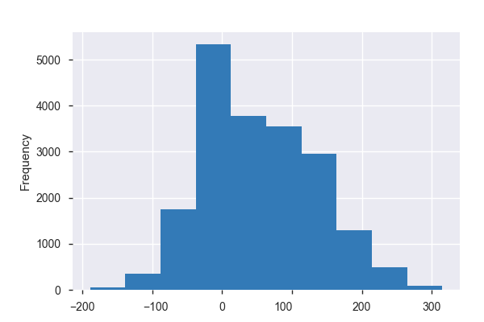

**Common Values**

| Value | Count | Frequency (%) |  |
| --- | --- | --- | --- |
| 2 | 258 | 1.3% |  |
| 44 | 245 | 1.2% |  |
| 48 | 236 | 1.2% |  |
| -41 | 175 | 0.9% |  |
| 39 | 153 | 0.8% |  |
| -1 | 138 | 0.7% |  |
| 4 | 131 | 0.7% |  |
| 0 | 129 | 0.7% |  |
| -3 | 127 | 0.6% |  |
| 3 | 126 | 0.6% |  |
| Other values (456) | 17904 | 91.2% |  |

**Extreme Values**

Minimum 5 values

| Value | Count | Frequency (%) |  |
| --- | --- | --- | --- |
| -189 | 1 | 0.0% |  |
| -182 | 2 | 0.0% |  |
| -181 | 1 | 0.0% |  |
| -179 | 1 | 0.0% |  |
| -176 | 2 | 0.0% |  |

Maximum 5 values

| Value | Count | Frequency (%) |  |
| --- | --- | --- | --- |
| 299 | 4 | 0.0% |  |
| 300 | 1 | 0.0% |  |
| 302 | 1 | 0.0% |  |
| 310 | 1 | 0.0% |  |
| 315 | 1 | 0.0% |  |

accel_dumbbell_z  
Numeric

| Distinct count | 410 |
| --- | --- |
| Unique (%) | 2.1% |
| Missing (%) | 0.0% |
| Missing (n) | 0 |
| Infinite (%) | 0.0% |
| Infinite (n) | 0 |

| Mean | -38.322 |
| --- | --- |
| Minimum | -334 |
| Maximum | 318 |
| Zeros (%) | 0.6% |

Toggle details

**Statistics**

Quantile statistics

| Minimum | -334 |
| --- | --- |
| 5-th percentile | -206 |
| Q1 | -142 |
| Median | -1 |
| Q3 | 38 |
| 95-th percentile | 98 |
| Maximum | 318 |
| Range | 652 |
| Interquartile range | 180 |

Descriptive statistics

| Standard deviation | 109.47 |
| --- | --- |
| Coef of variation | -2.8565 |
| Kurtosis | -0.54286 |
| Mean | -38.322 |
| MAD | 95.387 |
| Skewness | -0.10052 |
| Sum | -751962 |
| Variance | 11983 |
| Memory size | 153.4 KiB |

**Histogram**

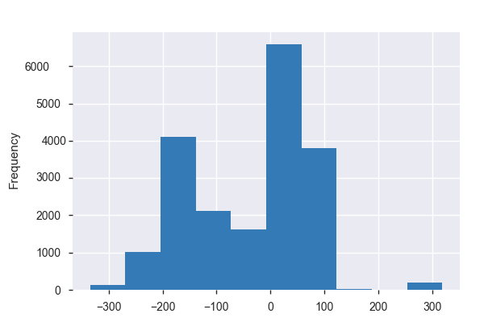

**Common Values**

| Value | Count | Frequency (%) |  |
| --- | --- | --- | --- |
| 15 | 272 | 1.4% |  |
| 6 | 240 | 1.2% |  |
| 13 | 215 | 1.1% |  |
| 81 | 210 | 1.1% |  |
| -11 | 206 | 1.0% |  |
| 10 | 205 | 1.0% |  |
| 9 | 194 | 1.0% |  |
| 11 | 190 | 1.0% |  |
| 12 | 188 | 1.0% |  |
| 14 | 184 | 0.9% |  |
| Other values (400) | 17518 | 89.3% |  |

**Extreme Values**

Minimum 5 values

| Value | Count | Frequency (%) |  |
| --- | --- | --- | --- |
| -334 | 1 | 0.0% |  |
| -319 | 1 | 0.0% |  |
| -284 | 1 | 0.0% |  |
| -273 | 3 | 0.0% |  |
| -272 | 36 | 0.2% |  |

Maximum 5 values

| Value | Count | Frequency (%) |  |
| --- | --- | --- | --- |
| 314 | 7 | 0.0% |  |
| 315 | 19 | 0.1% |  |
| 316 | 23 | 0.1% |  |
| 317 | 20 | 0.1% |  |
| 318 | 8 | 0.0% |  |

accel_forearm_x  
Numeric

| Distinct count | 794 |
| --- | --- |
| Unique (%) | 4.0% |
| Missing (%) | 0.0% |
| Missing (n) | 0 |
| Infinite (%) | 0.0% |
| Infinite (n) | 0 |

| Mean | -61.652 |
| --- | --- |
| Minimum | -498 |
| Maximum | 477 |
| Zeros (%) | 0.2% |

Toggle details

**Statistics**

Quantile statistics

| Minimum | -498 |
| --- | --- |
| 5-th percentile | -392 |
| Q1 | -178 |
| Median | -57 |
| Q3 | 76 |
| 95-th percentile | 223 |
| Maximum | 477 |
| Range | 975 |
| Interquartile range | 254 |

Descriptive statistics

| Standard deviation | 180.59 |
| --- | --- |
| Coef of variation | -2.9293 |
| Kurtosis | -0.68956 |
| Mean | -61.652 |
| MAD | 146.89 |
| Skewness | -0.2294 |
| Sum | -1209732 |
| Variance | 32614 |
| Memory size | 153.4 KiB |

**Histogram**

[figure not shown]

**Common Values**

| Value | Count | Frequency (%) |  |
| --- | --- | --- | --- |
| 192 | 98 | 0.5% |  |
| 193 | 87 | 0.4% |  |
| -57 | 84 | 0.4% |  |
| 191 | 79 | 0.4% |  |
| 195 | 76 | 0.4% |  |
| -55 | 72 | 0.4% |  |
| -54 | 70 | 0.4% |  |
| -56 | 68 | 0.3% |  |
| -58 | 67 | 0.3% |  |
| 194 | 67 | 0.3% |  |
| Other values (784) | 18854 | 96.1% |  |

**Extreme Values**

Minimum 5 values

| Value | Count | Frequency (%) |  |
| --- | --- | --- | --- |
| -498 | 1 | 0.0% |  |
| -496 | 1 | 0.0% |  |
| -487 | 1 | 0.0% |  |
| -479 | 1 | 0.0% |  |
| -477 | 1 | 0.0% |  |

Maximum 5 values

| Value | Count | Frequency (%) |  |
| --- | --- | --- | --- |
| 370 | 1 | 0.0% |  |
| 375 | 1 | 0.0% |  |
| 381 | 1 | 0.0% |  |
| 389 | 1 | 0.0% |  |
| 477 | 1 | 0.0% |  |

accel_forearm_y  
Numeric

| Distinct count | 1003 |
| --- | --- |
| Unique (%) | 5.1% |
| Missing (%) | 0.0% |
| Missing (n) | 0 |
| Infinite (%) | 0.0% |
| Infinite (n) | 0 |

| Mean | 163.66 |
| --- | --- |
| Minimum | -632 |
| Maximum | 923 |
| Zeros (%) | 0.2% |

Toggle details

**Statistics**

Quantile statistics

| Minimum | -632 |
| --- | --- |
| 5-th percentile | -227 |
| Q1 | 57 |
| Median | 201 |
| Q3 | 312 |
| 95-th percentile | 436 |
| Maximum | 923 |
| Range | 1555 |
| Interquartile range | 255 |

Descriptive statistics

| Standard deviation | 200.13 |
| --- | --- |
| Coef of variation | 1.2229 |
| Kurtosis | -0.11692 |
| Mean | 163.66 |
| MAD | 161.93 |
| Skewness | -0.65071 |
| Sum | 3211256 |
| Variance | 40052 |
| Memory size | 153.4 KiB |

**Histogram**

[figure not shown]

**Common Values**

| Value | Count | Frequency (%) |  |
| --- | --- | --- | --- |
| 278 | 107 | 0.5% |  |
| 279 | 101 | 0.5% |  |
| 102 | 94 | 0.5% |  |
| 99 | 87 | 0.4% |  |
| 280 | 86 | 0.4% |  |
| 100 | 85 | 0.4% |  |
| 101 | 85 | 0.4% |  |
| 203 | 82 | 0.4% |  |
| 202 | 79 | 0.4% |  |
| 107 | 77 | 0.4% |  |
| Other values (993) | 18739 | 95.5% |  |

**Extreme Values**

Minimum 5 values

| Value | Count | Frequency (%) |  |
| --- | --- | --- | --- |
| -632 | 1 | 0.0% |  |
| -595 | 1 | 0.0% |  |
| -585 | 1 | 0.0% |  |
| -537 | 1 | 0.0% |  |
| -496 | 2 | 0.0% |  |

Maximum 5 values

| Value | Count | Frequency (%) |  |
| --- | --- | --- | --- |
| 588 | 1 | 0.0% |  |
| 589 | 1 | 0.0% |  |
| 590 | 1 | 0.0% |  |
| 591 | 1 | 0.0% |  |
| 923 | 1 | 0.0% |  |

accel_forearm_z  
Numeric

| Distinct count | 580 |
| --- | --- |
| Unique (%) | 3.0% |
| Missing (%) | 0.0% |
| Missing (n) | 0 |
| Infinite (%) | 0.0% |
| Infinite (n) | 0 |

| Mean | -55.292 |
| --- | --- |
| Minimum | -446 |
| Maximum | 291 |
| Zeros (%) | 0.4% |

Toggle details

**Statistics**

Quantile statistics

| Minimum | -446 |
| --- | --- |
| 5-th percentile | -222 |
| Q1 | -182 |
| Median | -39 |
| Q3 | 26 |
| 95-th percentile | 199 |
| Maximum | 291 |
| Range | 737 |
| Interquartile range | 208 |

Descriptive statistics

| Standard deviation | 138.4 |
| --- | --- |
| Coef of variation | -2.503 |
| Kurtosis | -0.91016 |
| Mean | -55.292 |
| MAD | 120.14 |
| Skewness | 0.43649 |
| Sum | -1084938 |
| Variance | 19154 |
| Memory size | 153.4 KiB |

**Histogram**

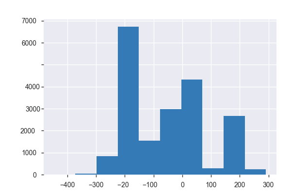

**Common Values**

| Value | Count | Frequency (%) |  |
| --- | --- | --- | --- |
| -200 | 161 | 0.8% |  |
| -201 | 160 | 0.8% |  |
| -199 | 146 | 0.7% |  |
| -202 | 143 | 0.7% |  |
| -204 | 138 | 0.7% |  |
| -203 | 134 | 0.7% |  |
| -215 | 132 | 0.7% |  |
| -214 | 128 | 0.7% |  |
| -179 | 120 | 0.6% |  |
| -168 | 120 | 0.6% |  |
| Other values (570) | 18240 | 93.0% |  |

**Extreme Values**

Minimum 5 values

| Value | Count | Frequency (%) |  |
| --- | --- | --- | --- |
| -446 | 1 | 0.0% |  |
| -410 | 1 | 0.0% |  |
| -391 | 1 | 0.0% |  |
| -386 | 1 | 0.0% |  |
| -381 | 1 | 0.0% |  |

Maximum 5 values

| Value | Count | Frequency (%) |  |
| --- | --- | --- | --- |
| 275 | 1 | 0.0% |  |
| 277 | 1 | 0.0% |  |
| 285 | 1 | 0.0% |  |
| 287 | 1 | 0.0% |  |
| 291 | 1 | 0.0% |  |

gyros_arm_x  
Numeric

| Distinct count | 643 |
| --- | --- |
| Unique (%) | 3.3% |
| Missing (%) | 0.0% |
| Missing (n) | 0 |
| Infinite (%) | 0.0% |
| Infinite (n) | 0 |

| Mean | 0.042772 |
| --- | --- |
| Minimum | -6.37 |
| Maximum | 4.87 |
| Zeros (%) | 2.6% |

Toggle details

**Statistics**

Quantile statistics

| Minimum | -6.37 |
| --- | --- |
| 5-th percentile | -3.48 |
| Q1 | -1.33 |
| Median | 0.08 |
| Q3 | 1.57 |
| 95-th percentile | 3.12 |
| Maximum | 4.87 |
| Range | 11.24 |
| Interquartile range | 2.9 |

Descriptive statistics

| Standard deviation | 1.9936 |
| --- | --- |
| Coef of variation | 46.609 |
| Kurtosis | -0.43074 |
| Mean | 0.042772 |
| MAD | 1.5593 |
| Skewness | -0.28774 |
| Sum | 839.28 |
| Variance | 3.9744 |
| Memory size | 153.4 KiB |

**Histogram**

[figure not shown]

**Common Values**

| Value | Count | Frequency (%) |  |
| --- | --- | --- | --- |
| 0.02 | 524 | 2.7% |  |
| 0.0 | 516 | 2.6% |  |
| -0.02 | 355 | 1.8% |  |
| 0.03 | 238 | 1.2% |  |
| 0.26 | 187 | 1.0% |  |
| 0.27 | 170 | 0.9% |  |
| -0.03 | 167 | 0.9% |  |
| 0.05 | 152 | 0.8% |  |
| 0.24 | 150 | 0.8% |  |
| 0.29 | 133 | 0.7% |  |
| Other values (633) | 17030 | 86.8% |  |

**Extreme Values**

Minimum 5 values

| Value | Count | Frequency (%) |  |
| --- | --- | --- | --- |
| -6.37 | 2 | 0.0% |  |
| -6.36 | 1 | 0.0% |  |
| -6.34 | 1 | 0.0% |  |
| -6.13 | 1 | 0.0% |  |
| -6.12 | 1 | 0.0% |  |

Maximum 5 values

| Value | Count | Frequency (%) |  |
| --- | --- | --- | --- |
| 4.7 | 1 | 0.0% |  |
| 4.74 | 1 | 0.0% |  |
| 4.78 | 1 | 0.0% |  |
| 4.82 | 1 | 0.0% |  |
| 4.87 | 3 | 0.0% |  |

gyros_arm_y  
Numeric

| Distinct count | 376 |
| --- | --- |
| Unique (%) | 1.9% |
| Missing (%) | 0.0% |
| Missing (n) | 0 |
| Infinite (%) | 0.0% |
| Infinite (n) | 0 |

| Mean | -0.25708 |
| --- | --- |
| Minimum | -3.44 |
| Maximum | 2.84 |
| Zeros (%) | 2.6% |

Toggle details

**Statistics**

Quantile statistics

| Minimum | -3.44 |
| --- | --- |
| 5-th percentile | -1.56 |
| Q1 | -0.8 |
| Median | -0.24 |
| Q3 | 0.14 |
| 95-th percentile | 1.27 |
| Maximum | 2.84 |
| Range | 6.28 |
| Interquartile range | 0.94 |

Descriptive statistics

| Standard deviation | 0.85139 |
| --- | --- |
| Coef of variation | -3.3118 |
| Kurtosis | 0.64695 |
| Mean | -0.25708 |
| MAD | 0.65295 |
| Skewness | 0.13523 |
| Sum | -5044.4 |
| Variance | 0.72487 |
| Memory size | 153.4 KiB |

**Histogram**

[figure not shown]

**Common Values**

| Value | Count | Frequency (%) |  |
| --- | --- | --- | --- |
| -0.02 | 749 | 3.8% |  |
| 0.0 | 515 | 2.6% |  |
| -0.03 | 474 | 2.4% |  |
| -0.05 | 302 | 1.5% |  |
| 0.02 | 293 | 1.5% |  |
| -0.5 | 279 | 1.4% |  |
| -0.51 | 249 | 1.3% |  |
| -0.53 | 226 | 1.2% |  |
| -0.56 | 203 | 1.0% |  |
| -0.06 | 198 | 1.0% |  |
| Other values (366) | 16134 | 82.2% |  |

**Extreme Values**

Minimum 5 values

| Value | Count | Frequency (%) |  |
| --- | --- | --- | --- |
| -3.44 | 1 | 0.0% |  |
| -3.4 | 1 | 0.0% |  |
| -3.37 | 1 | 0.0% |  |
| -3.32 | 1 | 0.0% |  |
| -3.29 | 1 | 0.0% |  |

Maximum 5 values

| Value | Count | Frequency (%) |  |
| --- | --- | --- | --- |
| 2.76 | 2 | 0.0% |  |
| 2.78 | 1 | 0.0% |  |
| 2.79 | 2 | 0.0% |  |
| 2.81 | 2 | 0.0% |  |
| 2.84 | 1 | 0.0% |  |

gyros_arm_z  
Numeric

| Distinct count | 248 |
| --- | --- |
| Unique (%) | 1.3% |
| Missing (%) | 0.0% |
| Missing (n) | 0 |
| Infinite (%) | 0.0% |
| Infinite (n) | 0 |

| Mean | 0.26948 |
| --- | --- |
| Minimum | -2.33 |
| Maximum | 3.02 |
| Zeros (%) | 2.7% |

Toggle details

**Statistics**

Quantile statistics

| Minimum | -2.33 |
| --- | --- |
| 5-th percentile | -0.67 |
| Q1 | -0.07 |
| Median | 0.23 |
| Q3 | 0.72 |
| 95-th percentile | 1.1 |
| Maximum | 3.02 |
| Range | 5.35 |
| Interquartile range | 0.79 |

Descriptive statistics

| Standard deviation | 0.55317 |
| --- | --- |
| Coef of variation | 2.0527 |
| Kurtosis | 0.04186 |
| Mean | 0.26948 |
| MAD | 0.45575 |
| Skewness | -0.17071 |
| Sum | 5287.7 |
| Variance | 0.306 |
| Memory size | 153.4 KiB |

**Histogram**

[figure not shown]

**Common Values**

| Value | Count | Frequency (%) |  |
| --- | --- | --- | --- |
| -0.02 | 582 | 3.0% |  |
| 0.0 | 524 | 2.7% |  |
| -0.03 | 392 | 2.0% |  |
| 0.02 | 373 | 1.9% |  |
| 0.03 | 289 | 1.5% |  |
| -0.07 | 275 | 1.4% |  |
| -0.05 | 273 | 1.4% |  |
| 0.79 | 266 | 1.4% |  |
| 0.77 | 262 | 1.3% |  |
| 0.8 | 259 | 1.3% |  |
| Other values (238) | 16127 | 82.2% |  |

**Extreme Values**

Minimum 5 values

| Value | Count | Frequency (%) |  |
| --- | --- | --- | --- |
| -2.33 | 1 | 0.0% |  |
| -2.28 | 1 | 0.0% |  |
| -2.17 | 1 | 0.0% |  |
| -2.13 | 1 | 0.0% |  |
| -2.1 | 1 | 0.0% |  |

Maximum 5 values

| Value | Count | Frequency (%) |  |
| --- | --- | --- | --- |
| 2.66 | 1 | 0.0% |  |
| 2.69 | 1 | 0.0% |  |
| 2.95 | 1 | 0.0% |  |
| 2.99 | 1 | 0.0% |  |
| 3.02 | 1 | 0.0% |  |

gyros_belt_x  
Numeric

| Distinct count | 140 |
| --- | --- |
| Unique (%) | 0.7% |
| Missing (%) | 0.0% |
| Missing (n) | 0 |
| Infinite (%) | 0.0% |
| Infinite (n) | 0 |

| Mean | -0.0055922 |
| --- | --- |
| Minimum | -1.04 |
| Maximum | 2.22 |
| Zeros (%) | 5.3% |

Toggle details

**Statistics**

Quantile statistics

| Minimum | -1.04 |
| --- | --- |
| 5-th percentile | -0.45 |
| Q1 | -0.03 |
| Median | 0.03 |
| Q3 | 0.11 |
| 95-th percentile | 0.21 |
| Maximum | 2.22 |
| Range | 3.26 |
| Interquartile range | 0.14 |

Descriptive statistics

| Standard deviation | 0.20733 |
| --- | --- |
| Coef of variation | -37.075 |
| Kurtosis | 6.5583 |
| Mean | -0.0055922 |
| MAD | 0.14061 |
| Skewness | -0.58304 |
| Sum | -109.73 |
| Variance | 0.042985 |
| Memory size | 153.4 KiB |

**Histogram**

[figure not shown]

**Common Values**

| Value | Count | Frequency (%) |  |
| --- | --- | --- | --- |
| 0.02 | 1444 | 7.4% |  |
| 0.11 | 1364 | 7.0% |  |
| 0.1 | 1250 | 6.4% |  |
| 0.03 | 1156 | 5.9% |  |
| 0.08 | 1135 | 5.8% |  |
| 0.13 | 1122 | 5.7% |  |
| 0.0 | 1039 | 5.3% |  |
| 0.06 | 1015 | 5.2% |  |
| 0.05 | 958 | 4.9% |  |
| -0.02 | 833 | 4.2% |  |
| Other values (130) | 8306 | 42.3% |  |

**Extreme Values**

Minimum 5 values

| Value | Count | Frequency (%) |  |
| --- | --- | --- | --- |
| -1.04 | 1 | 0.0% |  |
| -1.0 | 2 | 0.0% |  |
| -0.98 | 1 | 0.0% |  |
| -0.96 | 4 | 0.0% |  |
| -0.95 | 2 | 0.0% |  |

Maximum 5 values

| Value | Count | Frequency (%) |  |
| --- | --- | --- | --- |
| 1.88 | 1 | 0.0% |  |
| 1.98 | 1 | 0.0% |  |
| 2.02 | 1 | 0.0% |  |
| 2.2 | 1 | 0.0% |  |
| 2.22 | 1 | 0.0% |  |

gyros_belt_y  
Numeric

| Distinct count | 69 |
| --- | --- |
| Unique (%) | 0.4% |
| Missing (%) | 0.0% |
| Missing (n) | 0 |
| Infinite (%) | 0.0% |
| Infinite (n) | 0 |

| Mean | 0.039588 |
| --- | --- |
| Minimum | -0.64 |
| Maximum | 0.64 |
| Zeros (%) | 24.0% |

Toggle details

**Statistics**

Quantile statistics

| Minimum | -0.64 |
| --- | --- |
| 5-th percentile | -0.05 |
| Q1 | 0 |
| Median | 0.02 |
| Q3 | 0.11 |
| 95-th percentile | 0.13 |
| Maximum | 0.64 |
| Range | 1.28 |
| Interquartile range | 0.11 |

Descriptive statistics

| Standard deviation | 0.078236 |
| --- | --- |
| Coef of variation | 1.9763 |
| Kurtosis | 4.7207 |
| Mean | 0.039588 |
| MAD | 0.062908 |
| Skewness | -0.055182 |
| Sum | 776.79 |
| Variance | 0.0061208 |
| Memory size | 153.4 KiB |

**Histogram**

[figure not shown]

**Common Values**

| Value | Count | Frequency (%) |  |
| --- | --- | --- | --- |
| 0.0 | 4719 | 24.0% |  |
| 0.11 | 4125 | 21.0% |  |
| 0.02 | 2183 | 11.1% |  |
| -0.02 | 1900 | 9.7% |  |
| -0.03 | 1351 | 6.9% |  |
| 0.13 | 1185 | 6.0% |  |
| 0.1 | 858 | 4.4% |  |
| 0.03 | 496 | 2.5% |  |
| -0.05 | 478 | 2.4% |  |
| 0.14 | 306 | 1.6% |  |
| Other values (59) | 2021 | 10.3% |  |

**Extreme Values**

Minimum 5 values

| Value | Count | Frequency (%) |  |
| --- | --- | --- | --- |
| -0.64 | 1 | 0.0% |  |
| -0.53 | 1 | 0.0% |  |
| -0.51 | 1 | 0.0% |  |
| -0.48 | 1 | 0.0% |  |
| -0.45 | 3 | 0.0% |  |

Maximum 5 values

| Value | Count | Frequency (%) |  |
| --- | --- | --- | --- |
| 0.51 | 3 | 0.0% |  |
| 0.56 | 1 | 0.0% |  |
| 0.61 | 1 | 0.0% |  |
| 0.63 | 1 | 0.0% |  |
| 0.64 | 1 | 0.0% |  |

gyros_belt_z  
Numeric

| Distinct count | 169 |
| --- | --- |
| Unique (%) | 0.9% |
| Missing (%) | 0.0% |
| Missing (n) | 0 |
| Infinite (%) | 0.0% |
| Infinite (n) | 0 |

| Mean | -0.13054 |
| --- | --- |
| Minimum | -1.46 |
| Maximum | 1.62 |
| Zeros (%) | 9.0% |

Toggle details

**Statistics**

Quantile statistics

| Minimum | -1.46 |
| --- | --- |
| 5-th percentile | -0.49 |
| Q1 | -0.2 |
| Median | -0.1 |
| Q3 | -0.02 |
| 95-th percentile | 0.11 |
| Maximum | 1.62 |
| Range | 3.08 |
| Interquartile range | 0.18 |

Descriptive statistics

| Standard deviation | 0.24132 |
| --- | --- |
| Coef of variation | -1.8487 |
| Kurtosis | 6.2902 |
| Mean | -0.13054 |
| MAD | 0.16199 |
| Skewness | 0.20726 |
| Sum | -2561.4 |
| Variance | 0.058236 |
| Memory size | 153.4 KiB |

**Histogram**

[figure not shown]

**Common Values**

| Value | Count | Frequency (%) |  |
| --- | --- | --- | --- |
| -0.02 | 1884 | 9.6% |  |
| 0.0 | 1767 | 9.0% |  |
| -0.16 | 1606 | 8.2% |  |
| -0.18 | 1403 | 7.2% |  |
| -0.03 | 1281 | 6.5% |  |
| 0.02 | 1143 | 5.8% |  |
| -0.15 | 1007 | 5.1% |  |
| -0.05 | 892 | 4.5% |  |
| -0.2 | 714 | 3.6% |  |
| -0.44 | 534 | 2.7% |  |
| Other values (159) | 7391 | 37.7% |  |

**Extreme Values**

Minimum 5 values

| Value | Count | Frequency (%) |  |
| --- | --- | --- | --- |
| -1.46 | 1 | 0.0% |  |
| -1.35 | 1 | 0.0% |  |
| -1.33 | 1 | 0.0% |  |
| -1.3 | 1 | 0.0% |  |
| -1.28 | 1 | 0.0% |  |

Maximum 5 values

| Value | Count | Frequency (%) |  |
| --- | --- | --- | --- |
| 1.41 | 1 | 0.0% |  |
| 1.44 | 1 | 0.0% |  |
| 1.51 | 1 | 0.0% |  |
| 1.61 | 2 | 0.0% |  |
| 1.62 | 1 | 0.0% |  |

gyros_dumbbell_x  
Numeric

| Distinct count | 241 |
| --- | --- |
| Unique (%) | 1.2% |
| Missing (%) | 0.0% |
| Missing (n) | 0 |
| Infinite (%) | 0.0% |
| Infinite (n) | 0 |

| Mean | 0.16108 |
| --- | --- |
| Minimum | -204 |
| Maximum | 2.22 |
| Zeros (%) | 3.1% |

Toggle details

**Statistics**

Quantile statistics

| Minimum | -204 |
| --- | --- |
| 5-th percentile | -0.37 |
| Q1 | -0.03 |
| Median | 0.13 |
| Q3 | 0.35 |
| 95-th percentile | 0.83 |
| Maximum | 2.22 |
| Range | 206.22 |
| Interquartile range | 0.38 |

Descriptive statistics

| Standard deviation | 1.5086 |
| --- | --- |
| Coef of variation | 9.365 |
| Kurtosis | 17100 |
| Mean | 0.16108 |
| MAD | 0.28309 |
| Skewness | -126.34 |
| Sum | 3160.8 |
| Variance | 2.2757 |
| Memory size | 153.4 KiB |

**Histogram**

[figure not shown]

**Common Values**

| Value | Count | Frequency (%) |  |
| --- | --- | --- | --- |
| 0.0 | 614 | 3.1% |  |
| -0.02 | 612 | 3.1% |  |
| 0.13 | 581 | 3.0% |  |
| 0.35 | 554 | 2.8% |  |
| 0.02 | 548 | 2.8% |  |
| -0.03 | 497 | 2.5% |  |
| 0.14 | 486 | 2.5% |  |
| 0.16 | 481 | 2.5% |  |
| 0.34 | 455 | 2.3% |  |
| 0.1 | 454 | 2.3% |  |
| Other values (231) | 14340 | 73.1% |  |

**Extreme Values**

Minimum 5 values

| Value | Count | Frequency (%) |  |
| --- | --- | --- | --- |
| -204.0 | 1 | 0.0% |  |
| -1.99 | 2 | 0.0% |  |
| -1.94 | 1 | 0.0% |  |
| -1.86 | 1 | 0.0% |  |
| -1.85 | 2 | 0.0% |  |

Maximum 5 values

| Value | Count | Frequency (%) |  |
| --- | --- | --- | --- |
| 2.07 | 1 | 0.0% |  |
| 2.14 | 2 | 0.0% |  |
| 2.17 | 1 | 0.0% |  |
| 2.2 | 1 | 0.0% |  |
| 2.22 | 1 | 0.0% |  |

gyros_dumbbell_y  
Numeric

| Distinct count | 278 |
| --- | --- |
| Unique (%) | 1.4% |
| Missing (%) | 0.0% |
| Missing (n) | 0 |
| Infinite (%) | 0.0% |
| Infinite (n) | 0 |

| Mean | 0.046056 |
| --- | --- |
| Minimum | -2.1 |
| Maximum | 52 |
| Zeros (%) | 2.7% |

Toggle details

**Statistics**

Quantile statistics

| Minimum | -2.1 |
| --- | --- |
| 5-th percentile | -0.8 |
| Q1 | -0.14 |
| Median | 0.03 |
| Q3 | 0.21 |
| 95-th percentile | 0.92 |
| Maximum | 52 |
| Range | 54.1 |
| Interquartile range | 0.35 |

Descriptive statistics

| Standard deviation | 0.60999 |
| --- | --- |
| Coef of variation | 13.244 |
| Kurtosis | 2682.4 |
| Mean | 0.046056 |
| MAD | 0.32121 |
| Skewness | 31.653 |
| Sum | 903.72 |
| Variance | 0.37209 |
| Memory size | 153.4 KiB |

**Histogram**

[figure not shown]

**Common Values**

| Value | Count | Frequency (%) |  |
| --- | --- | --- | --- |
| 0.14 | 740 | 3.8% |  |
| -0.02 | 585 | 3.0% |  |
| 0.13 | 567 | 2.9% |  |
| 0.16 | 545 | 2.8% |  |
| 0.0 | 535 | 2.7% |  |
| -0.08 | 507 | 2.6% |  |
| 0.06 | 486 | 2.5% |  |
| 0.05 | 484 | 2.5% |  |
| 0.02 | 469 | 2.4% |  |
| 0.03 | 468 | 2.4% |  |
| Other values (268) | 14236 | 72.6% |  |

**Extreme Values**

Minimum 5 values

| Value | Count | Frequency (%) |  |
| --- | --- | --- | --- |
| -2.1 | 2 | 0.0% |  |
| -2.07 | 1 | 0.0% |  |
| -2.06 | 1 | 0.0% |  |
| -2.04 | 1 | 0.0% |  |
| -2.01 | 2 | 0.0% |  |

Maximum 5 values

| Value | Count | Frequency (%) |  |
| --- | --- | --- | --- |
| 2.63 | 1 | 0.0% |  |
| 2.71 | 1 | 0.0% |  |
| 2.73 | 2 | 0.0% |  |
| 4.37 | 1 | 0.0% |  |
| 52.0 | 1 | 0.0% |  |

gyros_dumbbell_z  
Numeric

| Distinct count | 206 |
| --- | --- |
| Unique (%) | 1.0% |
| Missing (%) | 0.0% |
| Missing (n) | 0 |
| Infinite (%) | 0.0% |
| Infinite (n) | 0 |

| Mean | -0.12899 |
| --- | --- |
| Minimum | -2.38 |
| Maximum | 317 |
| Zeros (%) | 3.1% |

Toggle details

**Statistics**

Quantile statistics

| Minimum | -2.38 |
| --- | --- |
| 5-th percentile | -0.67 |
| Q1 | -0.31 |
| Median | -0.13 |
| Q3 | 0.03 |
| 95-th percentile | 0.33 |
| Maximum | 317 |
| Range | 319.38 |
| Interquartile range | 0.34 |

Descriptive statistics

| Standard deviation | 2.2866 |
| --- | --- |
| Coef of variation | -17.727 |
| Kurtosis | 18859 |
| Mean | -0.12899 |
| MAD | 0.24522 |
| Skewness | 135.97 |
| Sum | -2531 |
| Variance | 5.2285 |
| Memory size | 153.4 KiB |

**Histogram**

[figure not shown]

**Common Values**

| Value | Count | Frequency (%) |  |
| --- | --- | --- | --- |
| -0.16 | 635 | 3.2% |  |
| 0.0 | 599 | 3.1% |  |
| 0.03 | 538 | 2.7% |  |
| -0.05 | 535 | 2.7% |  |
| -0.15 | 524 | 2.7% |  |
| -0.13 | 522 | 2.7% |  |
| -0.11 | 515 | 2.6% |  |
| 0.05 | 506 | 2.6% |  |
| -0.02 | 506 | 2.6% |  |
| -0.1 | 503 | 2.6% |  |
| Other values (196) | 14239 | 72.6% |  |

**Extreme Values**

Minimum 5 values

| Value | Count | Frequency (%) |  |
| --- | --- | --- | --- |
| -2.38 | 1 | 0.0% |  |
| -2.3 | 1 | 0.0% |  |
| -2.08 | 1 | 0.0% |  |
| -2.0 | 1 | 0.0% |  |
| -1.95 | 1 | 0.0% |  |

Maximum 5 values

| Value | Count | Frequency (%) |  |
| --- | --- | --- | --- |
| 1.61 | 2 | 0.0% |  |
| 1.67 | 1 | 0.0% |  |
| 1.72 | 1 | 0.0% |  |
| 1.87 | 1 | 0.0% |  |
| 317.0 | 1 | 0.0% |  |

gyros_forearm_x  
Numeric

| Distinct count | 298 |
| --- | --- |
| Unique (%) | 1.5% |
| Missing (%) | 0.0% |
| Missing (n) | 0 |
| Infinite (%) | 0.0% |
| Infinite (n) | 0 |

| Mean | 0.15795 |
| --- | --- |
| Minimum | -22 |
| Maximum | 3.97 |
| Zeros (%) | 2.7% |

Toggle details

**Statistics**

Quantile statistics

| Minimum | -22 |
| --- | --- |
| 5-th percentile | -0.75 |
| Q1 | -0.22 |
| Median | 0.05 |
| Q3 | 0.56 |
| 95-th percentile | 1.24 |
| Maximum | 3.97 |
| Range | 25.97 |
| Interquartile range | 0.78 |

Descriptive statistics

| Standard deviation | 0.64862 |
| --- | --- |
| Coef of variation | 4.1064 |
| Kurtosis | 69.91 |
| Mean | 0.15795 |
| MAD | 0.48847 |
| Skewness | -1.9241 |
| Sum | 3099.3 |
| Variance | 0.4207 |
| Memory size | 153.4 KiB |

**Histogram**

[figure not shown]

**Common Values**

| Value | Count | Frequency (%) |  |
| --- | --- | --- | --- |
| 0.02 | 554 | 2.8% |  |
| 0.0 | 523 | 2.7% |  |
| 0.03 | 432 | 2.2% |  |
| -0.02 | 413 | 2.1% |  |
| -0.03 | 322 | 1.6% |  |
| 0.05 | 319 | 1.6% |  |
| -0.05 | 286 | 1.5% |  |
| 0.06 | 263 | 1.3% |  |
| 0.08 | 263 | 1.3% |  |
| -0.06 | 259 | 1.3% |  |
| Other values (288) | 15988 | 81.5% |  |

**Extreme Values**

Minimum 5 values

| Value | Count | Frequency (%) |  |
| --- | --- | --- | --- |
| -22.0 | 1 | 0.0% |  |
| -4.95 | 1 | 0.0% |  |
| -3.36 | 1 | 0.0% |  |
| -3.08 | 1 | 0.0% |  |
| -2.99 | 1 | 0.0% |  |

Maximum 5 values

| Value | Count | Frequency (%) |  |
| --- | --- | --- | --- |
| 3.1 | 1 | 0.0% |  |
| 3.26 | 1 | 0.0% |  |
| 3.48 | 1 | 0.0% |  |
| 3.52 | 1 | 0.0% |  |
| 3.97 | 1 | 0.0% |  |

gyros_forearm_y  
Numeric

| Distinct count | 741 |
| --- | --- |
| Unique (%) | 3.8% |
| Missing (%) | 0.0% |
| Missing (n) | 0 |
| Infinite (%) | 0.0% |
| Infinite (n) | 0 |

| Mean | 0.075175 |
| --- | --- |
| Minimum | -7.02 |
| Maximum | 311 |
| Zeros (%) | 2.0% |

Toggle details

**Statistics**

Quantile statistics

| Minimum | -7.02 |
| --- | --- |
| 5-th percentile | -3.61 |
| Q1 | -1.46 |
| Median | 0.03 |
| Q3 | 1.62 |
| 95-th percentile | 3.5 |
| Maximum | 311 |
| Range | 318.02 |
| Interquartile range | 3.08 |

Descriptive statistics

| Standard deviation | 3.1007 |
| --- | --- |
| Coef of variation | 41.247 |
| Kurtosis | 5152.1 |
| Mean | 0.075175 |
| MAD | 1.7163 |
| Skewness | 51.332 |
| Sum | 1475.1 |
| Variance | 9.6145 |
| Memory size | 153.4 KiB |

**Histogram**

[figure not shown]

**Common Values**

| Value | Count | Frequency (%) |  |
| --- | --- | --- | --- |
| -0.02 | 397 | 2.0% |  |
| 0.0 | 383 | 2.0% |  |
| -0.03 | 279 | 1.4% |  |
| 0.02 | 239 | 1.2% |  |
| 0.03 | 196 | 1.0% |  |
| 0.06 | 178 | 0.9% |  |
| 0.05 | 173 | 0.9% |  |
| -0.05 | 159 | 0.8% |  |
| 0.08 | 137 | 0.7% |  |
| -0.06 | 129 | 0.7% |  |
| Other values (731) | 17352 | 88.4% |  |

**Extreme Values**

Minimum 5 values

| Value | Count | Frequency (%) |  |
| --- | --- | --- | --- |
| -7.02 | 1 | 0.0% |  |
| -6.65 | 1 | 0.0% |  |
| -6.62 | 1 | 0.0% |  |
| -6.54 | 1 | 0.0% |  |
| -6.52 | 2 | 0.0% |  |

Maximum 5 values

| Value | Count | Frequency (%) |  |
| --- | --- | --- | --- |
| 6.09 | 1 | 0.0% |  |
| 6.1 | 1 | 0.0% |  |
| 6.12 | 1 | 0.0% |  |
| 6.13 | 4 | 0.0% |  |
| 311.0 | 1 | 0.0% |  |

gyros_forearm_z  
Highly correlated

*This variable is highly correlated with `gyros_dumbbell_z` and should be ignored for analysis*

| Correlation | 0.93304 |
| --- | --- |

magnet_arm_x  
Numeric

| Distinct count | 1339 |
| --- | --- |
| Unique (%) | 6.8% |
| Missing (%) | 0.0% |
| Missing (n) | 0 |
| Infinite (%) | 0.0% |
| Infinite (n) | 0 |

| Mean | 191.72 |
| --- | --- |
| Minimum | -584 |
| Maximum | 782 |
| Zeros (%) | 0.0% |

Toggle details

**Statistics**

Quantile statistics

| Minimum | -584 |
| --- | --- |
| 5-th percentile | -422 |
| Q1 | -300 |
| Median | 289 |
| Q3 | 637 |
| 95-th percentile | 744 |
| Maximum | 782 |
| Range | 1366 |
| Interquartile range | 937 |

Descriptive statistics

| Standard deviation | 443.64 |
| --- | --- |
| Coef of variation | 2.314 |
| Kurtosis | -1.6006 |
| Mean | 191.72 |
| MAD | 408.57 |
| Skewness | -0.15497 |
| Sum | 3761988 |
| Variance | 196820 |
| Memory size | 153.4 KiB |

**Histogram**

[figure not shown]

**Common Values**

| Value | Count | Frequency (%) |  |
| --- | --- | --- | --- |
| 728 | 86 | 0.4% |  |
| -422 | 86 | 0.4% |  |
| 730 | 85 | 0.4% |  |
| 735 | 82 | 0.4% |  |
| -425 | 82 | 0.4% |  |
| -368 | 80 | 0.4% |  |
| -424 | 78 | 0.4% |  |
| -423 | 76 | 0.4% |  |
| 732 | 75 | 0.4% |  |
| -367 | 73 | 0.4% |  |
| Other values (1329) | 18819 | 95.9% |  |

**Extreme Values**

Minimum 5 values

| Value | Count | Frequency (%) |  |
| --- | --- | --- | --- |
| -584 | 1 | 0.0% |  |
| -580 | 2 | 0.0% |  |
| -579 | 1 | 0.0% |  |
| -578 | 2 | 0.0% |  |
| -576 | 2 | 0.0% |  |

Maximum 5 values

| Value | Count | Frequency (%) |  |
| --- | --- | --- | --- |
| 777 | 4 | 0.0% |  |
| 778 | 4 | 0.0% |  |
| 779 | 2 | 0.0% |  |
| 780 | 2 | 0.0% |  |
| 782 | 1 | 0.0% |  |

magnet_arm_y  
Numeric

| Distinct count | 872 |
| --- | --- |
| Unique (%) | 4.4% |
| Missing (%) | 0.0% |
| Missing (n) | 0 |
| Infinite (%) | 0.0% |
| Infinite (n) | 0 |

| Mean | 156.61 |
| --- | --- |
| Minimum | -392 |
| Maximum | 583 |
| Zeros (%) | 0.1% |

Toggle details

**Statistics**

Quantile statistics

| Minimum | -392 |
| --- | --- |
| 5-th percentile | -200 |
| Q1 | -9 |
| Median | 202 |
| Q3 | 323 |
| 95-th percentile | 435 |
| Maximum | 583 |
| Range | 975 |
| Interquartile range | 332 |

Descriptive statistics

| Standard deviation | 201.91 |
| --- | --- |
| Coef of variation | 1.2892 |
| Kurtosis | -0.82846 |
| Mean | 156.61 |
| MAD | 172.54 |
| Skewness | -0.46747 |
| Sum | 3073027 |
| Variance | 40768 |
| Memory size | 153.4 KiB |

**Histogram**

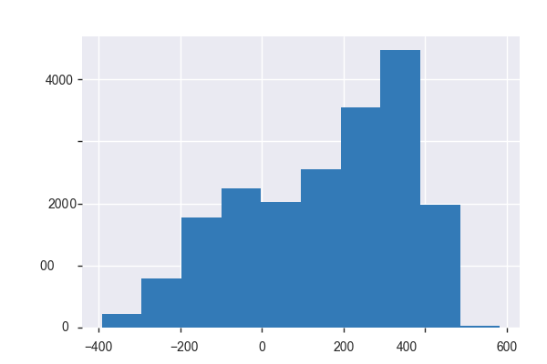

**Common Values**

| Value | Count | Frequency (%) |  |
| --- | --- | --- | --- |
| 335 | 93 | 0.5% |  |
| 337 | 88 | 0.4% |  |
| 330 | 84 | 0.4% |  |
| 336 | 79 | 0.4% |  |
| 338 | 78 | 0.4% |  |
| 340 | 73 | 0.4% |  |
| 332 | 73 | 0.4% |  |
| 339 | 73 | 0.4% |  |
| 319 | 70 | 0.4% |  |
| 342 | 70 | 0.4% |  |
| Other values (862) | 18841 | 96.0% |  |

**Extreme Values**

Minimum 5 values

| Value | Count | Frequency (%) |  |
| --- | --- | --- | --- |
| -392 | 1 | 0.0% |  |
| -386 | 1 | 0.0% |  |
| -384 | 1 | 0.0% |  |
| -381 | 1 | 0.0% |  |
| -377 | 1 | 0.0% |  |

Maximum 5 values

| Value | Count | Frequency (%) |  |
| --- | --- | --- | --- |
| 577 | 2 | 0.0% |  |
| 578 | 2 | 0.0% |  |
| 580 | 2 | 0.0% |  |
| 582 | 2 | 0.0% |  |
| 583 | 1 | 0.0% |  |

magnet_arm_z  
Numeric

| Distinct count | 1265 |
| --- | --- |
| Unique (%) | 6.4% |
| Missing (%) | 0.0% |
| Missing (n) | 0 |
| Infinite (%) | 0.0% |
| Infinite (n) | 0 |

| Mean | 306.49 |
| --- | --- |
| Minimum | -597 |
| Maximum | 694 |
| Zeros (%) | 0.0% |

Toggle details

**Statistics**

Quantile statistics

| Minimum | -597 |
| --- | --- |
| 5-th percentile | -420 |
| Q1 | 131.25 |
| Median | 444 |
| Q3 | 545 |
| 95-th percentile | 620 |
| Maximum | 694 |
| Range | 1291 |
| Interquartile range | 413.75 |

Descriptive statistics

| Standard deviation | 326.62 |
| --- | --- |
| Coef of variation | 1.0657 |
| Kurtosis | 0.10071 |
| Mean | 306.49 |
| MAD | 267.68 |
| Skewness | -1.1405 |
| Sum | 6013966 |
| Variance | 106680 |
| Memory size | 153.4 KiB |

**Histogram**

[figure not shown]

**Common Values**

| Value | Count | Frequency (%) |  |
| --- | --- | --- | --- |
| 511 | 114 | 0.6% |  |
| 510 | 110 | 0.6% |  |
| 514 | 108 | 0.6% |  |
| 515 | 106 | 0.5% |  |
| 513 | 99 | 0.5% |  |
| 512 | 92 | 0.5% |  |
| 509 | 85 | 0.4% |  |
| 508 | 84 | 0.4% |  |
| 559 | 79 | 0.4% |  |
| 560 | 78 | 0.4% |  |
| Other values (1255) | 18667 | 95.1% |  |

**Extreme Values**

Minimum 5 values

| Value | Count | Frequency (%) |  |
| --- | --- | --- | --- |
| -597 | 1 | 0.0% |  |
| -596 | 1 | 0.0% |  |
| -595 | 1 | 0.0% |  |
| -590 | 2 | 0.0% |  |
| -586 | 1 | 0.0% |  |

Maximum 5 values

| Value | Count | Frequency (%) |  |
| --- | --- | --- | --- |
| 685 | 2 | 0.0% |  |
| 687 | 1 | 0.0% |  |
| 690 | 1 | 0.0% |  |
| 693 | 1 | 0.0% |  |
| 694 | 1 | 0.0% |  |

magnet_belt_x  
Numeric

| Distinct count | 327 |
| --- | --- |
| Unique (%) | 1.7% |
| Missing (%) | 0.0% |
| Missing (n) | 0 |
| Infinite (%) | 0.0% |
| Infinite (n) | 0 |

| Mean | 55.601 |
| --- | --- |
| Minimum | -52 |
| Maximum | 485 |
| Zeros (%) | 1.8% |

Toggle details

**Statistics**

Quantile statistics

| Minimum | -52 |
| --- | --- |
| 5-th percentile | -4 |
| Q1 | 9 |
| Median | 35 |
| Q3 | 59 |
| 95-th percentile | 173 |
| Maximum | 485 |
| Range | 537 |
| Interquartile range | 50 |

Descriptive statistics

| Standard deviation | 64.179 |
| --- | --- |
| Coef of variation | 1.1543 |
| Kurtosis | 2.1012 |
| Mean | 55.601 |
| MAD | 49.525 |
| Skewness | 1.4334 |
| Sum | 1091000 |
| Variance | 4119 |
| Memory size | 153.4 KiB |

**Histogram**

[figure not shown]

**Common Values**

| Value | Count | Frequency (%) |  |
| --- | --- | --- | --- |
| 1 | 387 | 2.0% |  |
| 3 | 355 | 1.8% |  |
| 0 | 350 | 1.8% |  |
| 2 | 343 | 1.7% |  |
| 4 | 324 | 1.7% |  |
| 48 | 318 | 1.6% |  |
| 5 | 309 | 1.6% |  |
| 6 | 298 | 1.5% |  |
| 8 | 294 | 1.5% |  |
| -1 | 293 | 1.5% |  |
| Other values (317) | 16351 | 83.3% |  |

**Extreme Values**

Minimum 5 values

| Value | Count | Frequency (%) |  |
| --- | --- | --- | --- |
| -52 | 1 | 0.0% |  |
| -49 | 1 | 0.0% |  |
| -48 | 1 | 0.0% |  |
| -46 | 1 | 0.0% |  |
| -45 | 1 | 0.0% |  |

Maximum 5 values

| Value | Count | Frequency (%) |  |
| --- | --- | --- | --- |
| 474 | 1 | 0.0% |  |
| 476 | 1 | 0.0% |  |
| 479 | 1 | 0.0% |  |
| 481 | 1 | 0.0% |  |
| 485 | 1 | 0.0% |  |

magnet_belt_y  
Numeric

| Distinct count | 298 |
| --- | --- |
| Unique (%) | 1.5% |
| Missing (%) | 0.0% |
| Missing (n) | 0 |
| Infinite (%) | 0.0% |
| Infinite (n) | 0 |

| Mean | 593.68 |
| --- | --- |
| Minimum | 354 |
| Maximum | 673 |
| Zeros (%) | 0.0% |

Toggle details

**Statistics**

Quantile statistics

| Minimum | 354 |
| --- | --- |
| 5-th percentile | 525.05 |
| Q1 | 581 |
| Median | 601 |
| Q3 | 610 |
| 95-th percentile | 635 |
| Maximum | 673 |
| Range | 319 |
| Interquartile range | 29 |

Descriptive statistics

| Standard deviation | 35.681 |
| --- | --- |
| Coef of variation | 0.060101 |
| Kurtosis | 7.9765 |
| Mean | 593.68 |
| MAD | 23.776 |
| Skewness | -2.2362 |
| Sum | 11649130 |
| Variance | 1273.1 |
| Memory size | 153.4 KiB |

**Histogram**

[figure not shown]

**Common Values**

| Value | Count | Frequency (%) |  |
| --- | --- | --- | --- |
| 602 | 706 | 3.6% |  |
| 607 | 642 | 3.3% |  |
| 606 | 606 | 3.1% |  |
| 601 | 592 | 3.0% |  |
| 603 | 591 | 3.0% |  |
| 600 | 580 | 3.0% |  |
| 604 | 561 | 2.9% |  |
| 605 | 548 | 2.8% |  |
| 599 | 509 | 2.6% |  |
| 608 | 437 | 2.2% |  |
| Other values (288) | 13850 | 70.6% |  |

**Extreme Values**

Minimum 5 values

| Value | Count | Frequency (%) |  |
| --- | --- | --- | --- |
| 354 | 1 | 0.0% |  |
| 359 | 1 | 0.0% |  |
| 360 | 1 | 0.0% |  |
| 363 | 1 | 0.0% |  |
| 365 | 2 | 0.0% |  |

Maximum 5 values

| Value | Count | Frequency (%) |  |
| --- | --- | --- | --- |
| 666 | 1 | 0.0% |  |
| 667 | 2 | 0.0% |  |
| 668 | 1 | 0.0% |  |
| 669 | 1 | 0.0% |  |
| 673 | 1 | 0.0% |  |

magnet_belt_z  
Numeric

| Distinct count | 457 |
| --- | --- |
| Unique (%) | 2.3% |
| Missing (%) | 0.0% |
| Missing (n) | 0 |
| Infinite (%) | 0.0% |
| Infinite (n) | 0 |

| Mean | -345.48 |
| --- | --- |
| Minimum | -623 |
| Maximum | 293 |
| Zeros (%) | 0.0% |

Toggle details

**Statistics**

Quantile statistics

| Minimum | -623 |
| --- | --- |
| 5-th percentile | -452 |
| Q1 | -375 |
| Median | -320 |
| Q3 | -306 |
| 95-th percentile | -291 |
| Maximum | 293 |
| Range | 916 |
| Interquartile range | 69 |

Descriptive statistics

| Standard deviation | 65.21 |
| --- | --- |
| Coef of variation | -0.18875 |
| Kurtosis | 12.353 |
| Mean | -345.48 |
| MAD | 48.83 |
| Skewness | 0.1727 |
| Sum | -6779025 |
| Variance | 4252.3 |
| Memory size | 153.4 KiB |

**Histogram**

[figure not shown]

**Common Values**

| Value | Count | Frequency (%) |  |
| --- | --- | --- | --- |
| -304 | 474 | 2.4% |  |
| -312 | 471 | 2.4% |  |
| -305 | 448 | 2.3% |  |
| -303 | 442 | 2.3% |  |
| -307 | 440 | 2.2% |  |
| -306 | 436 | 2.2% |  |
| -311 | 420 | 2.1% |  |
| -309 | 404 | 2.1% |  |
| -308 | 402 | 2.0% |  |
| -313 | 386 | 2.0% |  |
| Other values (447) | 15299 | 78.0% |  |

**Extreme Values**

Minimum 5 values

| Value | Count | Frequency (%) |  |
| --- | --- | --- | --- |
| -623 | 1 | 0.0% |  |
| -621 | 2 | 0.0% |  |
| -620 | 1 | 0.0% |  |
| -618 | 2 | 0.0% |  |
| -616 | 1 | 0.0% |  |

Maximum 5 values

| Value | Count | Frequency (%) |  |
| --- | --- | --- | --- |
| 284 | 3 | 0.0% |  |
| 286 | 1 | 0.0% |  |
| 287 | 1 | 0.0% |  |
| 289 | 1 | 0.0% |  |
| 293 | 1 | 0.0% |  |

magnet_dumbbell_x  
Numeric

| Distinct count | 1128 |
| --- | --- |
| Unique (%) | 5.7% |
| Missing (%) | 0.0% |
| Missing (n) | 0 |
| Infinite (%) | 0.0% |
| Infinite (n) | 0 |

| Mean | -328.48 |
| --- | --- |
| Minimum | -643 |
| Maximum | 592 |
| Zeros (%) | 0.0% |

Toggle details

**Statistics**

Quantile statistics

| Minimum | -643 |
| --- | --- |
| 5-th percentile | -579 |
| Q1 | -535 |
| Median | -479 |
| Q3 | -304 |
| 95-th percentile | 520 |
| Maximum | 592 |
| Range | 1235 |
| Interquartile range | 231 |

Descriptive statistics

| Standard deviation | 339.72 |
| --- | --- |
| Coef of variation | -1.0342 |
| Kurtosis | 1.4443 |
| Mean | -328.48 |
| MAD | 251.99 |
| Skewness | 1.6943 |
| Sum | -6445450 |
| Variance | 115410 |
| Memory size | 153.4 KiB |

**Histogram**

[figure not shown]

**Common Values**

| Value | Count | Frequency (%) |  |
| --- | --- | --- | --- |
| -504 | 190 | 1.0% |  |
| -505 | 173 | 0.9% |  |
| -519 | 158 | 0.8% |  |
| -265 | 154 | 0.8% |  |
| -469 | 151 | 0.8% |  |
| -363 | 142 | 0.7% |  |
| -527 | 139 | 0.7% |  |
| -521 | 139 | 0.7% |  |
| -520 | 136 | 0.7% |  |
| -552 | 135 | 0.7% |  |
| Other values (1118) | 18105 | 92.3% |  |

**Extreme Values**

Minimum 5 values

| Value | Count | Frequency (%) |  |
| --- | --- | --- | --- |
| -643 | 1 | 0.0% |  |
| -639 | 2 | 0.0% |  |
| -638 | 2 | 0.0% |  |
| -637 | 1 | 0.0% |  |
| -635 | 2 | 0.0% |  |

Maximum 5 values

| Value | Count | Frequency (%) |  |
| --- | --- | --- | --- |
| 579 | 1 | 0.0% |  |
| 582 | 1 | 0.0% |  |
| 583 | 3 | 0.0% |  |
| 584 | 1 | 0.0% |  |
| 592 | 1 | 0.0% |  |

magnet_dumbbell_y  
Numeric

| Distinct count | 844 |
| --- | --- |
| Unique (%) | 4.3% |
| Missing (%) | 0.0% |
| Missing (n) | 0 |
| Infinite (%) | 0.0% |
| Infinite (n) | 0 |

| Mean | 220.97 |
| --- | --- |
| Minimum | -3600 |
| Maximum | 633 |
| Zeros (%) | 0.0% |

Toggle details

**Statistics**

Quantile statistics

| Minimum | -3600 |
| --- | --- |
| 5-th percentile | -562 |
| Q1 | 231 |
| Median | 311 |
| Q3 | 390 |
| 95-th percentile | 551 |
| Maximum | 633 |
| Range | 4233 |
| Interquartile range | 159 |

Descriptive statistics

| Standard deviation | 326.87 |
| --- | --- |
| Coef of variation | 1.4793 |
| Kurtosis | 2.7835 |
| Mean | 220.97 |
| MAD | 218.63 |
| Skewness | -1.8101 |
| Sum | 4335779 |
| Variance | 106840 |
| Memory size | 153.4 KiB |

**Histogram**

[figure not shown]

**Common Values**

| Value | Count | Frequency (%) |  |
| --- | --- | --- | --- |
| 318 | 212 | 1.1% |  |
| 230 | 177 | 0.9% |  |
| 501 | 134 | 0.7% |  |
| 402 | 133 | 0.7% |  |
| 126 | 127 | 0.6% |  |
| 504 | 124 | 0.6% |  |
| 296 | 119 | 0.6% |  |
| 295 | 116 | 0.6% |  |
| 166 | 116 | 0.6% |  |
| 294 | 114 | 0.6% |  |
| Other values (834) | 18250 | 93.0% |  |

**Extreme Values**

Minimum 5 values

| Value | Count | Frequency (%) |  |
| --- | --- | --- | --- |
| -3600 | 1 | 0.0% |  |
| -744 | 1 | 0.0% |  |
| -742 | 1 | 0.0% |  |
| -741 | 2 | 0.0% |  |
| -740 | 1 | 0.0% |  |

Maximum 5 values

| Value | Count | Frequency (%) |  |
| --- | --- | --- | --- |
| 629 | 6 | 0.0% |  |
| 630 | 3 | 0.0% |  |
| 631 | 6 | 0.0% |  |
| 632 | 5 | 0.0% |  |
| 633 | 1 | 0.0% |  |

magnet_dumbbell_z  
Numeric

| Distinct count | 676 |
| --- | --- |
| Unique (%) | 3.4% |
| Missing (%) | 0.0% |
| Missing (n) | 0 |
| Infinite (%) | 0.0% |
| Infinite (n) | 0 |

| Mean | 46.054 |
| --- | --- |
| Minimum | -262 |
| Maximum | 452 |
| Zeros (%) | 0.5% |

Toggle details

**Statistics**

Quantile statistics

| Minimum | -262 |
| --- | --- |
| 5-th percentile | -152 |
| Q1 | -45 |
| Median | 13 |
| Q3 | 95 |
| 95-th percentile | 345 |
| Maximum | 452 |
| Range | 714 |
| Interquartile range | 140 |

Descriptive statistics

| Standard deviation | 139.96 |
| --- | --- |
| Coef of variation | 3.0391 |
| Kurtosis | 0.27525 |
| Mean | 46.054 |
| MAD | 106.72 |
| Skewness | 0.87774 |
| Sum | 903670 |
| Variance | 19590 |
| Memory size | 153.4 KiB |

**Histogram**

[figure not shown]

**Common Values**

| Value | Count | Frequency (%) |  |
| --- | --- | --- | --- |
| -49.0 | 196 | 1.0% |  |
| -31.0 | 192 | 1.0% |  |
| 375.0 | 157 | 0.8% |  |
| -2.0 | 152 | 0.8% |  |
| 275.0 | 152 | 0.8% |  |
| -40.0 | 114 | 0.6% |  |
| 248.0 | 109 | 0.6% |  |
| -16.0 | 109 | 0.6% |  |
| -7.0 | 105 | 0.5% |  |
| 308.0 | 105 | 0.5% |  |
| Other values (666) | 18231 | 92.9% |  |

**Extreme Values**

Minimum 5 values

| Value | Count | Frequency (%) |  |
| --- | --- | --- | --- |
| -262.0 | 1 | 0.0% |  |
| -250.0 | 1 | 0.0% |  |
| -249.0 | 1 | 0.0% |  |
| -248.0 | 1 | 0.0% |  |
| -245.0 | 3 | 0.0% |  |

Maximum 5 values

| Value | Count | Frequency (%) |  |
| --- | --- | --- | --- |
| 442.0 | 1 | 0.0% |  |
| 443.0 | 3 | 0.0% |  |
| 447.0 | 1 | 0.0% |  |
| 451.0 | 2 | 0.0% |  |
| 452.0 | 1 | 0.0% |  |

magnet_forearm_x  
Numeric

| Distinct count | 1524 |
| --- | --- |
| Unique (%) | 7.8% |
| Missing (%) | 0.0% |
| Missing (n) | 0 |
| Infinite (%) | 0.0% |
| Infinite (n) | 0 |

| Mean | -312.58 |
| --- | --- |
| Minimum | -1280 |
| Maximum | 672 |
| Zeros (%) | 0.1% |

Toggle details

**Statistics**

Quantile statistics

| Minimum | -1280 |
| --- | --- |
| 5-th percentile | -700 |
| Q1 | -616 |
| Median | -378 |
| Q3 | -73 |
| 95-th percentile | 379 |
| Maximum | 672 |
| Range | 1952 |
| Interquartile range | 543 |

Descriptive statistics

| Standard deviation | 346.96 |
| --- | --- |
| Coef of variation | -1.11 |
| Kurtosis | -0.07683 |
| Mean | -312.58 |
| MAD | 290.4 |
| Skewness | 0.64339 |
| Sum | -6133364 |
| Variance | 120380 |
| Memory size | 153.4 KiB |

**Histogram**

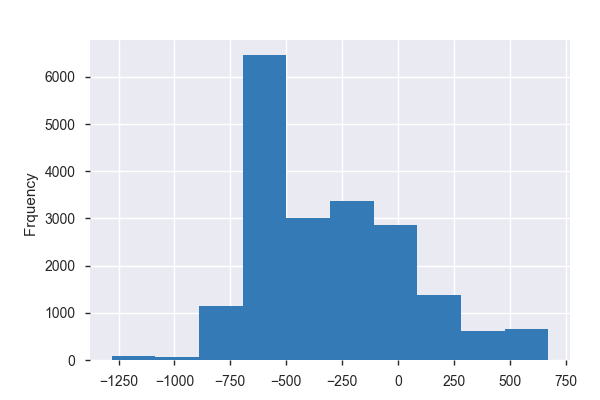

**Common Values**

| Value | Count | Frequency (%) |  |
| --- | --- | --- | --- |
| -679 | 82 | 0.4% |  |
| -678 | 81 | 0.4% |  |
| -687 | 74 | 0.4% |  |
| -677 | 73 | 0.4% |  |
| -686 | 71 | 0.4% |  |
| -682 | 70 | 0.4% |  |
| -695 | 70 | 0.4% |  |
| -670 | 68 | 0.3% |  |
| -685 | 68 | 0.3% |  |
| -692 | 66 | 0.3% |  |
| Other values (1514) | 18899 | 96.3% |  |

**Extreme Values**

Minimum 5 values

| Value | Count | Frequency (%) |  |
| --- | --- | --- | --- |
| -1280 | 5 | 0.0% |  |
| -1270 | 41 | 0.2% |  |
| -1260 | 10 | 0.1% |  |
| -1250 | 4 | 0.0% |  |
| -1240 | 7 | 0.0% |  |

Maximum 5 values

| Value | Count | Frequency (%) |  |
| --- | --- | --- | --- |
| 660 | 7 | 0.0% |  |
| 661 | 5 | 0.0% |  |
| 663 | 1 | 0.0% |  |
| 666 | 1 | 0.0% |  |
| 672 | 1 | 0.0% |  |

magnet_forearm_y  
Numeric

| Distinct count | 1872 |
| --- | --- |
| Unique (%) | 9.5% |
| Missing (%) | 0.0% |
| Missing (n) | 0 |
| Infinite (%) | 0.0% |
| Infinite (n) | 0 |

| Mean | 380.12 |
| --- | --- |
| Minimum | -896 |
| Maximum | 1480 |
| Zeros (%) | 0.0% |

Toggle details

**Statistics**

Quantile statistics

| Minimum | -896 |
| --- | --- |
| 5-th percentile | -632.95 |
| Q1 | 2 |
| Median | 591 |
| Q3 | 737 |
| 95-th percentile | 981 |
| Maximum | 1480 |
| Range | 2376 |
| Interquartile range | 735 |

Descriptive statistics

| Standard deviation | 509.37 |
| --- | --- |
| Coef of variation | 1.34 |
| Kurtosis | -0.45477 |
| Mean | 380.12 |
| MAD | 427.82 |
| Skewness | -0.74458 |
| Sum | 7458600 |
| Variance | 259460 |
| Memory size | 153.4 KiB |

**Histogram**

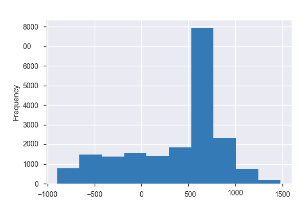

**Common Values**

| Value | Count | Frequency (%) |  |
| --- | --- | --- | --- |
| 1180.0 | 101 | 0.5% |  |
| 752.0 | 81 | 0.4% |  |
| 1170.0 | 79 | 0.4% |  |
| 775.0 | 79 | 0.4% |  |
| 749.0 | 77 | 0.4% |  |
| 743.0 | 72 | 0.4% |  |
| 751.0 | 72 | 0.4% |  |
| 1190.0 | 71 | 0.4% |  |
| 654.0 | 68 | 0.3% |  |
| 720.0 | 67 | 0.3% |  |
| Other values (1862) | 18855 | 96.1% |  |

**Extreme Values**

Minimum 5 values

| Value | Count | Frequency (%) |  |
| --- | --- | --- | --- |
| -896.0 | 1 | 0.0% |  |
| -892.0 | 1 | 0.0% |  |
| -890.0 | 1 | 0.0% |  |
| -885.0 | 1 | 0.0% |  |
| -882.0 | 2 | 0.0% |  |

Maximum 5 values

| Value | Count | Frequency (%) |  |
| --- | --- | --- | --- |
| 1430.0 | 12 | 0.1% |  |
| 1440.0 | 28 | 0.1% |  |
| 1450.0 | 22 | 0.1% |  |
| 1460.0 | 1 | 0.0% |  |
| 1480.0 | 1 | 0.0% |  |

magnet_forearm_z  
Numeric

| Distinct count | 1683 |
| --- | --- |
| Unique (%) | 8.6% |
| Missing (%) | 0.0% |
| Missing (n) | 0 |
| Infinite (%) | 0.0% |
| Infinite (n) | 0 |

| Mean | 393.61 |
| --- | --- |
| Minimum | -973 |
| Maximum | 1090 |
| Zeros (%) | 0.0% |

Toggle details

**Statistics**

Quantile statistics

| Minimum | -973 |
| --- | --- |
| 5-th percentile | -453 |
| Q1 | 191 |
| Median | 511 |
| Q3 | 653 |
| 95-th percentile | 799 |
| Maximum | 1090 |
| Range | 2063 |
| Interquartile range | 462 |

Descriptive statistics

| Standard deviation | 369.27 |
| --- | --- |
| Coef of variation | 0.93815 |
| Kurtosis | 0.90048 |
| Mean | 393.61 |
| MAD | 290.25 |
| Skewness | -1.2212 |
| Sum | 7723500 |
| Variance | 136360 |
| Memory size | 153.4 KiB |

**Histogram**

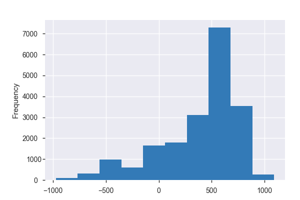

**Common Values**

| Value | Count | Frequency (%) |  |
| --- | --- | --- | --- |
| 659.0 | 58 | 0.3% |  |
| 471.0 | 58 | 0.3% |  |
| 664.0 | 57 | 0.3% |  |
| 662.0 | 57 | 0.3% |  |
| 470.0 | 56 | 0.3% |  |
| 663.0 | 55 | 0.3% |  |
| 661.0 | 55 | 0.3% |  |
| 665.0 | 53 | 0.3% |  |
| 696.0 | 53 | 0.3% |  |
| 467.0 | 52 | 0.3% |  |
| Other values (1673) | 19068 | 97.2% |  |

**Extreme Values**

Minimum 5 values

| Value | Count | Frequency (%) |  |
| --- | --- | --- | --- |
| -973.0 | 1 | 0.0% |  |
| -966.0 | 3 | 0.0% |  |
| -964.0 | 2 | 0.0% |  |
| -963.0 | 2 | 0.0% |  |
| -962.0 | 3 | 0.0% |  |

Maximum 5 values

| Value | Count | Frequency (%) |  |
| --- | --- | --- | --- |
| 1040.0 | 3 | 0.0% |  |
| 1050.0 | 3 | 0.0% |  |
| 1070.0 | 2 | 0.0% |  |
| 1080.0 | 1 | 0.0% |  |
| 1090.0 | 1 | 0.0% |  |

pitch_arm  
Numeric

| Distinct count | 3087 |
| --- | --- |
| Unique (%) | 15.7% |
| Missing (%) | 0.0% |
| Missing (n) | 0 |
| Infinite (%) | 0.0% |
| Infinite (n) | 0 |

| Mean | -4.6119 |
| --- | --- |
| Minimum | -88.8 |
| Maximum | 88.5 |
| Zeros (%) | 17.3% |

Toggle details

**Statistics**

Quantile statistics

| Minimum | -88.8 |
| --- | --- |
| 5-th percentile | -56 |
| Q1 | -25.9 |
| Median | 0 |
| Q3 | 11.2 |
| 95-th percentile | 51.1 |
| Maximum | 88.5 |
| Range | 177.3 |
| Interquartile range | 37.1 |

Descriptive statistics

| Standard deviation | 30.682 |
| --- | --- |
| Coef of variation | -6.6527 |
| Kurtosis | 0.28557 |
| Mean | -4.6119 |
| MAD | 23.398 |
| Skewness | 0.20342 |
| Sum | -90495 |
| Variance | 941.38 |
| Memory size | 153.4 KiB |

**Histogram**

[figure not shown]

**Common Values**

| Value | Count | Frequency (%) |  |
| --- | --- | --- | --- |
| 0.0 | 3403 | 17.3% |  |
| 43.3 | 39 | 0.2% |  |
| 43.2 | 36 | 0.2% |  |
| -26.3 | 33 | 0.2% |  |
| 12.0 | 31 | 0.2% |  |
| -31.6 | 31 | 0.2% |  |
| -31.0 | 30 | 0.2% |  |
| 11.1 | 30 | 0.2% |  |
| -29.5 | 30 | 0.2% |  |
| -26.8 | 30 | 0.2% |  |
| Other values (3077) | 15929 | 81.2% |  |

**Extreme Values**

Minimum 5 values

| Value | Count | Frequency (%) |  |
| --- | --- | --- | --- |
| -88.8 | 1 | 0.0% |  |
| -88.2 | 1 | 0.0% |  |
| -87.9 | 1 | 0.0% |  |
| -87.8 | 2 | 0.0% |  |
| -87.7 | 1 | 0.0% |  |

Maximum 5 values

| Value | Count | Frequency (%) |  |
| --- | --- | --- | --- |
| 86.6 | 1 | 0.0% |  |
| 86.8 | 1 | 0.0% |  |
| 87.1 | 1 | 0.0% |  |
| 88.2 | 1 | 0.0% |  |
| 88.5 | 1 | 0.0% |  |

pitch_belt  
Numeric

| Distinct count | 1840 |
| --- | --- |
| Unique (%) | 9.4% |
| Missing (%) | 0.0% |
| Missing (n) | 0 |
| Infinite (%) | 0.0% |
| Infinite (n) | 0 |

| Mean | 0.30528 |
| --- | --- |
| Minimum | -55.8 |
| Maximum | 60.3 |
| Zeros (%) | 0.0% |

Toggle details

**Statistics**

Quantile statistics

| Minimum | -55.8 |
| --- | --- |
| 5-th percentile | -43.6 |
| Q1 | 1.76 |
| Median | 5.28 |
| Q3 | 14.9 |
| 95-th percentile | 26.2 |
| Maximum | 60.3 |
| Range | 116.1 |
| Interquartile range | 13.14 |

Descriptive statistics

| Standard deviation | 22.351 |
| --- | --- |
| Coef of variation | 73.215 |
| Kurtosis | -0.090902 |
| Mean | 0.30528 |
| MAD | 16.711 |
| Skewness | -1.0017 |
| Sum | 5990.3 |
| Variance | 499.58 |
| Memory size | 153.4 KiB |

**Histogram**

[figure not shown]

**Common Values**

| Value | Count | Frequency (%) |  |
| --- | --- | --- | --- |
| -43.7 | 201 | 1.0% |  |
| -43.8 | 194 | 1.0% |  |
| 25.8 | 159 | 0.8% |  |
| -43.5 | 149 | 0.8% |  |
| 25.9 | 147 | 0.7% |  |
| 16.3 | 146 | 0.7% |  |
| 25.5 | 135 | 0.7% |  |
| -43.9 | 128 | 0.7% |  |
| 25.2 | 126 | 0.6% |  |
| -43.4 | 124 | 0.6% |  |
| Other values (1830) | 18113 | 92.3% |  |

**Extreme Values**

Minimum 5 values

| Value | Count | Frequency (%) |  |
| --- | --- | --- | --- |
| -55.8 | 1 | 0.0% |  |
| -54.9 | 1 | 0.0% |  |
| -54.7 | 1 | 0.0% |  |
| -54.4 | 1 | 0.0% |  |
| -53.9 | 2 | 0.0% |  |

Maximum 5 values

| Value | Count | Frequency (%) |  |
| --- | --- | --- | --- |
| 59.9 | 3 | 0.0% |  |
| 60.0 | 3 | 0.0% |  |
| 60.1 | 3 | 0.0% |  |
| 60.2 | 1 | 0.0% |  |
| 60.3 | 2 | 0.0% |  |

pitch_dumbbell  
Numeric

| Distinct count | 16040 |
| --- | --- |
| Unique (%) | 81.7% |
| Missing (%) | 0.0% |
| Missing (n) | 0 |
| Infinite (%) | 0.0% |
| Infinite (n) | 0 |

| Mean | -10.779 |
| --- | --- |
| Minimum | -149.59 |
| Maximum | 149.4 |
| Zeros (%) | 1.6% |

Toggle details

**Statistics**

Quantile statistics

| Minimum | -149.59 |
| --- | --- |
| 5-th percentile | -56.443 |
| Q1 | -40.887 |
| Median | -20.958 |
| Q3 | 17.499 |
| 95-th percentile | 51.34 |
| Maximum | 149.4 |
| Range | 299 |
| Interquartile range | 58.386 |

Descriptive statistics

| Standard deviation | 36.994 |
| --- | --- |
| Coef of variation | -3.4319 |
| Kurtosis | -0.13277 |
| Mean | -10.779 |
| MAD | 31.266 |
| Skewness | 0.52243 |
| Sum | -211510 |
| Variance | 1368.5 |
| Memory size | 153.4 KiB |

**Histogram**

[figure not shown]

**Common Values**

| Value | Count | Frequency (%) |  |
| --- | --- | --- | --- |
| 0.0 | 312 | 1.6% |  |
| 16.83261367 | 137 | 0.7% |  |
| -38.22207697 | 121 | 0.6% |  |
| 41.53224862 | 117 | 0.6% |  |
| -43.75878888 | 105 | 0.5% |  |
| 27.18691566 | 102 | 0.5% |  |
| -43.96087351 | 91 | 0.5% |  |
| -61.30623892 | 78 | 0.4% |  |
| 17.91394808 | 31 | 0.2% |  |
| 38.68158188 | 26 | 0.1% |  |
| Other values (16030) | 18502 | 94.3% |  |

**Extreme Values**

Minimum 5 values

| Value | Count | Frequency (%) |  |
| --- | --- | --- | --- |
| -149.5936479 | 1 | 0.0% |  |
| -148.5004814 | 1 | 0.0% |  |
| -137.3400767 | 1 | 0.0% |  |
| -134.7319726 | 1 | 0.0% |  |
| -130.1046141 | 1 | 0.0% |  |

Maximum 5 values

| Value | Count | Frequency (%) |  |
| --- | --- | --- | --- |
| 127.93395320000002 | 1 | 0.0% |  |
| 129.5153528 | 1 | 0.0% |  |
| 129.8243452 | 1 | 0.0% |  |
| 137.0249969 | 1 | 0.0% |  |
| 149.4024436 | 1 | 0.0% |  |

pitch_forearm  
Numeric

| Distinct count | 2915 |
| --- | --- |
| Unique (%) | 14.9% |
| Missing (%) | 0.0% |
| Missing (n) | 0 |
| Infinite (%) | 0.0% |
| Infinite (n) | 0 |

| Mean | 10.706 |
| --- | --- |
| Minimum | -72.5 |
| Maximum | 89.8 |
| Zeros (%) | 19.8% |

Toggle details

**Statistics**

Quantile statistics

| Minimum | -72.5 |
| --- | --- |
| 5-th percentile | -51.4 |
| Q1 | 0 |
| Median | 9.24 |
| Q3 | 28.4 |
| 95-th percentile | 54 |
| Maximum | 89.8 |
| Range | 162.3 |
| Interquartile range | 28.4 |

Descriptive statistics

| Standard deviation | 28.146 |
| --- | --- |
| Coef of variation | 2.629 |
| Kurtosis | 0.87909 |
| Mean | 10.706 |
| MAD | 20.894 |
| Skewness | -0.51037 |
| Sum | 210070 |
| Variance | 792.17 |
| Memory size | 153.4 KiB |

**Histogram**

[figure not shown]

**Common Values**

| Value | Count | Frequency (%) |  |
| --- | --- | --- | --- |
| 0.0 | 3893 | 19.8% |  |
| -63.5 | 59 | 0.3% |  |
| -63.7 | 58 | 0.3% |  |
| -63.6 | 52 | 0.3% |  |
| -63.8 | 45 | 0.2% |  |
| -63.9 | 43 | 0.2% |  |
| 14.1 | 40 | 0.2% |  |
| 13.5 | 40 | 0.2% |  |
| 11.7 | 39 | 0.2% |  |
| 12.6 | 39 | 0.2% |  |
| Other values (2905) | 15314 | 78.0% |  |

**Extreme Values**

Minimum 5 values

| Value | Count | Frequency (%) |  |
| --- | --- | --- | --- |
| -72.5 | 3 | 0.0% |  |
| -72.4 | 2 | 0.0% |  |
| -72.1 | 1 | 0.0% |  |
| -71.6 | 2 | 0.0% |  |
| -71.4 | 1 | 0.0% |  |

Maximum 5 values

| Value | Count | Frequency (%) |  |
| --- | --- | --- | --- |
| 87.5 | 1 | 0.0% |  |
| 87.9 | 1 | 0.0% |  |
| 88.4 | 1 | 0.0% |  |
| 88.7 | 1 | 0.0% |  |
| 89.8 | 1 | 0.0% |  |

roll_arm  
Numeric

| Distinct count | 2654 |
| --- | --- |
| Unique (%) | 13.5% |
| Missing (%) | 0.0% |
| Missing (n) | 0 |
| Infinite (%) | 0.0% |
| Infinite (n) | 0 |

| Mean | 17.83 |
| --- | --- |
| Minimum | -180 |
| Maximum | 180 |
| Zeros (%) | 17.3% |

Toggle details

**Statistics**

Quantile statistics

| Minimum | -180 |
| --- | --- |
| 5-th percentile | -117 |
| Q1 | -31.775 |
| Median | 0 |
| Q3 | 77.3 |
| 95-th percentile | 135 |
| Maximum | 180 |
| Range | 360 |
| Interquartile range | 109.08 |

Descriptive statistics

| Standard deviation | 72.744 |
| --- | --- |
| Coef of variation | 4.0798 |
| Kurtosis | -0.40952 |
| Mean | 17.83 |
| MAD | 60.036 |
| Skewness | -0.17608 |
| Sum | 349860 |
| Variance | 5291.7 |
| Memory size | 153.4 KiB |

**Histogram**

[figure not shown]

**Common Values**

| Value | Count | Frequency (%) |  |
| --- | --- | --- | --- |
| 0.0 | 3402 | 17.3% |  |
| -141.0 | 65 | 0.3% |  |
| 104.0 | 61 | 0.3% |  |
| 139.0 | 60 | 0.3% |  |
| -137.0 | 56 | 0.3% |  |
| 121.0 | 55 | 0.3% |  |
| 125.0 | 55 | 0.3% |  |
| 118.0 | 55 | 0.3% |  |
| 124.0 | 54 | 0.3% |  |
| 134.0 | 54 | 0.3% |  |
| Other values (2644) | 15705 | 80.0% |  |

**Extreme Values**

Minimum 5 values

| Value | Count | Frequency (%) |  |
| --- | --- | --- | --- |
| -180.0 | 3 | 0.0% |  |
| -178.0 | 4 | 0.0% |  |
| -177.0 | 5 | 0.0% |  |
| -176.0 | 10 | 0.1% |  |
| -175.0 | 15 | 0.1% |  |

Maximum 5 values

| Value | Count | Frequency (%) |  |
| --- | --- | --- | --- |
| 176.0 | 5 | 0.0% |  |
| 177.0 | 5 | 0.0% |  |
| 178.0 | 3 | 0.0% |  |
| 179.0 | 5 | 0.0% |  |
| 180.0 | 2 | 0.0% |  |

roll_belt  
Numeric

| Distinct count | 1330 |
| --- | --- |
| Unique (%) | 6.8% |
| Missing (%) | 0.0% |
| Missing (n) | 0 |
| Infinite (%) | 0.0% |
| Infinite (n) | 0 |

| Mean | 64.407 |
| --- | --- |
| Minimum | -28.9 |
| Maximum | 162 |
| Zeros (%) | 0.0% |

Toggle details

**Statistics**

Quantile statistics

| Minimum | -28.9 |
| --- | --- |
| 5-th percentile | -0.2 |
| Q1 | 1.1 |
| Median | 113 |
| Q3 | 123 |
| 95-th percentile | 139 |
| Maximum | 162 |
| Range | 190.9 |
| Interquartile range | 121.9 |

Descriptive statistics

| Standard deviation | 62.75 |
| --- | --- |
| Coef of variation | 0.97427 |
| Kurtosis | -1.9315 |
| Mean | 64.407 |
| MAD | 62.3 |
| Skewness | -0.016198 |
| Sum | 1263800 |
| Variance | 3937.6 |
| Memory size | 153.4 KiB |

**Histogram**

[figure not shown]

**Common Values**

| Value | Count | Frequency (%) |  |
| --- | --- | --- | --- |
| 121.0 | 984 | 5.0% |  |
| 122.0 | 893 | 4.6% |  |
| 124.0 | 731 | 3.7% |  |
| 127.0 | 631 | 3.2% |  |
| 119.0 | 622 | 3.2% |  |
| 125.0 | 618 | 3.1% |  |
| 126.0 | 556 | 2.8% |  |
| 120.0 | 540 | 2.8% |  |
| 123.0 | 516 | 2.6% |  |
| 118.0 | 482 | 2.5% |  |
| Other values (1320) | 13049 | 66.5% |  |

**Extreme Values**

Minimum 5 values

| Value | Count | Frequency (%) |  |
| --- | --- | --- | --- |
| -28.9 | 1 | 0.0% |  |
| -28.8 | 1 | 0.0% |  |
| -28.6 | 2 | 0.0% |  |
| -28.4 | 1 | 0.0% |  |
| -28.3 | 2 | 0.0% |  |

Maximum 5 values

| Value | Count | Frequency (%) |  |
| --- | --- | --- | --- |
| 158.0 | 38 | 0.2% |  |
| 159.0 | 27 | 0.1% |  |
| 160.0 | 22 | 0.1% |  |
| 161.0 | 11 | 0.1% |  |
| 162.0 | 5 | 0.0% |  |

roll_dumbbell  
Numeric

| Distinct count | 16523 |
| --- | --- |
| Unique (%) | 84.2% |
| Missing (%) | 0.0% |
| Missing (n) | 0 |
| Infinite (%) | 0.0% |
| Infinite (n) | 0 |

| Mean | 23.842 |
| --- | --- |
| Minimum | -153.71 |
| Maximum | 153.55 |
| Zeros (%) | 0.7% |

Toggle details

**Statistics**

Quantile statistics

| Minimum | -153.71 |
| --- | --- |
| 5-th percentile | -110.15 |
| Q1 | -18.493 |
| Median | 48.174 |
| Q3 | 67.614 |
| 95-th percentile | 116.28 |
| Maximum | 153.55 |
| Range | 307.26 |
| Interquartile range | 86.107 |

Descriptive statistics

| Standard deviation | 69.932 |
| --- | --- |
| Coef of variation | 2.9332 |
| Kurtosis | -0.44013 |
| Mean | 23.842 |
| MAD | 57.482 |
| Skewness | -0.73964 |
| Sum | 467820 |
| Variance | 4890.4 |
| Memory size | 153.4 KiB |

**Histogram**

[figure not shown]

**Common Values**

| Value | Count | Frequency (%) |  |
| --- | --- | --- | --- |
| 52.66002952 | 137 | 0.7% |  |
| 0.0 | 134 | 0.7% |  |
| -101.5169348 | 121 | 0.6% |  |
| 109.225388 | 117 | 0.6% |  |
| 5.653088706 | 106 | 0.5% |  |
| 125.9931686 | 102 | 0.5% |  |
| -107.4901385 | 91 | 0.5% |  |
| 11.85790659 | 78 | 0.4% |  |
| 91.39534214 | 31 | 0.2% |  |
| -1.714817745 | 26 | 0.1% |  |
| Other values (16513) | 18679 | 95.2% |  |

**Extreme Values**

Minimum 5 values

| Value | Count | Frequency (%) |  |
| --- | --- | --- | --- |
| -153.7137292 | 1 | 0.0% |  |
| -153.50972140000002 | 1 | 0.0% |  |
| -152.82687919999998 | 1 | 0.0% |  |
| -152.42452319999998 | 1 | 0.0% |  |
| -152.0331583 | 2 | 0.0% |  |

Maximum 5 values

| Value | Count | Frequency (%) |  |
| --- | --- | --- | --- |
| 151.0 | 1 | 0.0% |  |
| 151.3523953 | 1 | 0.0% |  |
| 152.08379309999998 | 1 | 0.0% |  |
| 153.3776211 | 1 | 0.0% |  |
| 153.5455708 | 1 | 0.0% |  |

roll_forearm  
Numeric

| Distinct count | 2176 |
| --- | --- |
| Unique (%) | 11.1% |
| Missing (%) | 0.0% |
| Missing (n) | 0 |
| Infinite (%) | 0.0% |
| Infinite (n) | 0 |

| Mean | 33.827 |
| --- | --- |
| Minimum | -180 |
| Maximum | 180 |
| Zeros (%) | 19.8% |

Toggle details

**Statistics**

Quantile statistics

| Minimum | -180 |
| --- | --- |
| 5-th percentile | -175 |
| Q1 | -0.7375 |
| Median | 21.7 |
| Q3 | 140 |
| 95-th percentile | 174 |
| Maximum | 180 |
| Range | 360 |
| Interquartile range | 140.74 |

Descriptive statistics

| Standard deviation | 108.04 |
| --- | --- |
| Coef of variation | 3.1938 |
| Kurtosis | -0.75747 |
| Mean | 33.827 |
| MAD | 89.532 |
| Skewness | -0.46447 |
| Sum | 663740 |
| Variance | 11672 |
| Memory size | 153.4 KiB |

**Histogram**

[figure not shown]

**Common Values**

| Value | Count | Frequency (%) |  |
| --- | --- | --- | --- |
| 0.0 | 3894 | 19.8% |  |
| 148.0 | 336 | 1.7% |  |
| -179.0 | 221 | 1.1% |  |
| -178.0 | 219 | 1.1% |  |
| 149.0 | 215 | 1.1% |  |
| 147.0 | 205 | 1.0% |  |
| -176.0 | 199 | 1.0% |  |
| -177.0 | 199 | 1.0% |  |
| 150.0 | 184 | 0.9% |  |
| 179.0 | 182 | 0.9% |  |
| Other values (2166) | 13768 | 70.2% |  |

**Extreme Values**

Minimum 5 values

| Value | Count | Frequency (%) |  |
| --- | --- | --- | --- |
| -180.0 | 94 | 0.5% |  |
| -179.0 | 221 | 1.1% |  |
| -178.0 | 219 | 1.1% |  |
| -177.0 | 199 | 1.0% |  |
| -176.0 | 199 | 1.0% |  |

Maximum 5 values

| Value | Count | Frequency (%) |  |
| --- | --- | --- | --- |
| 176.0 | 144 | 0.7% |  |
| 177.0 | 155 | 0.8% |  |
| 178.0 | 163 | 0.8% |  |
| 179.0 | 182 | 0.9% |  |
| 180.0 | 79 | 0.4% |  |

yaw_arm  
Numeric

| Distinct count | 2876 |
| --- | --- |
| Unique (%) | 14.7% |
| Missing (%) | 0.0% |
| Missing (n) | 0 |
| Infinite (%) | 0.0% |
| Infinite (n) | 0 |

| Mean | -0.61875 |
| --- | --- |
| Minimum | -180 |
| Maximum | 180 |
| Zeros (%) | 17.3% |

Toggle details

**Statistics**

Quantile statistics

| Minimum | -180 |
| --- | --- |
| 5-th percentile | -128 |
| Q1 | -43.1 |
| Median | 0 |
| Q3 | 45.875 |
| 95-th percentile | 116 |
| Maximum | 180 |
| Range | 360 |
| Interquartile range | 88.975 |

Descriptive statistics

| Standard deviation | 71.363 |
| --- | --- |
| Coef of variation | -115.33 |
| Kurtosis | -0.13084 |
| Mean | -0.61875 |
| MAD | 53.833 |
| Skewness | -0.091938 |
| Sum | -12141 |
| Variance | 5092.7 |
| Memory size | 153.4 KiB |

**Histogram**

[figure not shown]

**Common Values**

| Value | Count | Frequency (%) |  |
| --- | --- | --- | --- |
| 0.0 | 3402 | 17.3% |  |
| 115.0 | 103 | 0.5% |  |
| 116.0 | 101 | 0.5% |  |
| 114.0 | 89 | 0.5% |  |
| 113.0 | 87 | 0.4% |  |
| 118.0 | 76 | 0.4% |  |
| 112.0 | 71 | 0.4% |  |
| -171.0 | 68 | 0.3% |  |
| -162.0 | 66 | 0.3% |  |
| 105.0 | 64 | 0.3% |  |
| Other values (2866) | 15495 | 79.0% |  |

**Extreme Values**

Minimum 5 values

| Value | Count | Frequency (%) |  |
| --- | --- | --- | --- |
| -180.0 | 6 | 0.0% |  |
| -179.0 | 3 | 0.0% |  |
| -178.0 | 5 | 0.0% |  |
| -177.0 | 12 | 0.1% |  |
| -176.0 | 33 | 0.2% |  |

Maximum 5 values

| Value | Count | Frequency (%) |  |
| --- | --- | --- | --- |
| 176.0 | 8 | 0.0% |  |
| 177.0 | 11 | 0.1% |  |
| 178.0 | 9 | 0.0% |  |
| 179.0 | 6 | 0.0% |  |
| 180.0 | 6 | 0.0% |  |

yaw_belt  
Numeric

| Distinct count | 1957 |
| --- | --- |
| Unique (%) | 10.0% |
| Missing (%) | 0.0% |
| Missing (n) | 0 |
| Infinite (%) | 0.0% |
| Infinite (n) | 0 |

| Mean | -11.205 |
| --- | --- |
| Minimum | -180 |
| Maximum | 179 |
| Zeros (%) | 0.0% |

Toggle details

**Statistics**

Quantile statistics

| Minimum | -180 |
| --- | --- |
| 5-th percentile | -93.5 |
| Q1 | -88.3 |
| Median | -13 |
| Q3 | 12.9 |
| 95-th percentile | 168 |
| Maximum | 179 |
| Range | 359 |
| Interquartile range | 101.2 |

Descriptive statistics

| Standard deviation | 95.194 |
| --- | --- |
| Coef of variation | -8.4956 |
| Kurtosis | -0.58219 |
| Mean | -11.205 |
| MAD | 77.112 |
| Skewness | 0.90733 |
| Sum | -219870 |
| Variance | 9061.9 |
| Memory size | 153.4 KiB |

**Histogram**

[figure not shown]

**Common Values**

| Value | Count | Frequency (%) |  |
| --- | --- | --- | --- |
| -88.0 | 543 | 2.8% |  |
| -87.9 | 513 | 2.6% |  |
| -87.8 | 441 | 2.2% |  |
| 165.0 | 422 | 2.2% |  |
| 166.0 | 415 | 2.1% |  |
| -88.1 | 411 | 2.1% |  |
| 164.0 | 395 | 2.0% |  |
| -88.2 | 380 | 1.9% |  |
| -88.3 | 359 | 1.8% |  |
| -87.7 | 337 | 1.7% |  |
| Other values (1947) | 15406 | 78.5% |  |

**Extreme Values**

Minimum 5 values

| Value | Count | Frequency (%) |  |
| --- | --- | --- | --- |
| -180.0 | 1 | 0.0% |  |
| -179.0 | 5 | 0.0% |  |
| -178.0 | 5 | 0.0% |  |
| -177.0 | 3 | 0.0% |  |
| -176.0 | 4 | 0.0% |  |

Maximum 5 values

| Value | Count | Frequency (%) |  |
| --- | --- | --- | --- |
| 175.0 | 8 | 0.0% |  |
| 176.0 | 6 | 0.0% |  |
| 177.0 | 13 | 0.1% |  |
| 178.0 | 28 | 0.1% |  |
| 179.0 | 20 | 0.1% |  |

yaw_dumbbell  
Numeric

| Distinct count | 16381 |
| --- | --- |
| Unique (%) | 83.5% |
| Missing (%) | 0.0% |
| Missing (n) | 0 |
| Infinite (%) | 0.0% |
| Infinite (n) | 0 |

| Mean | 1.6744 |
| --- | --- |
| Minimum | -150.87 |
| Maximum | 154.95 |
| Zeros (%) | 0.6% |

Toggle details

**Statistics**

Quantile statistics

| Minimum | -150.87 |
| --- | --- |
| 5-th percentile | -102.42 |
| Q1 | -77.644 |
| Median | -3.3238 |
| Q3 | 79.643 |
| 95-th percentile | 129.06 |
| Maximum | 154.95 |
| Range | 305.82 |
| Interquartile range | 157.29 |

Descriptive statistics

| Standard deviation | 82.517 |
| --- | --- |
| Coef of variation | 49.283 |
| Kurtosis | -1.4292 |
| Mean | 1.6744 |
| MAD | 74.285 |
| Skewness | 0.2169 |
| Sum | 32854 |
| Variance | 6809.1 |
| Memory size | 153.4 KiB |

**Histogram**

[figure not shown]

**Common Values**

| Value | Count | Frequency (%) |  |
| --- | --- | --- | --- |
| 101.2450579 | 137 | 0.7% |  |
| -38.22207697 | 121 | 0.6% |  |
| -22.37798097 | 117 | 0.6% |  |
| 0.0 | 114 | 0.6% |  |
| -112.9064176 | 105 | 0.5% |  |
| 14.70010832 | 102 | 0.5% |  |
| 21.44322519 | 91 | 0.5% |  |
| 94.29405816 | 78 | 0.4% |  |
| 62.37017162 | 31 | 0.2% |  |
| 118.35598859999999 | 26 | 0.1% |  |
| Other values (16371) | 18700 | 95.3% |  |

**Extreme Values**

Minimum 5 values

| Value | Count | Frequency (%) |  |
| --- | --- | --- | --- |
| -150.87115419999998 | 1 | 0.0% |  |
| -148.7655095 | 1 | 0.0% |  |
| -147.11276740000002 | 1 | 0.0% |  |
| -146.24367809999998 | 1 | 0.0% |  |
| -144.3427108 | 1 | 0.0% |  |

Maximum 5 values

| Value | Count | Frequency (%) |  |
| --- | --- | --- | --- |
| 154.1342065 | 1 | 0.0% |  |
| 154.2232669 | 1 | 0.0% |  |
| 154.5160918 | 1 | 0.0% |  |
| 154.7544704 | 1 | 0.0% |  |
| 154.9522941 | 1 | 0.0% |  |

yaw_forearm  
Numeric

| Distinct count | 1991 |
| --- | --- |
| Unique (%) | 10.1% |
| Missing (%) | 0.0% |
| Missing (n) | 0 |
| Infinite (%) | 0.0% |
| Infinite (n) | 0 |

| Mean | 19.208 |
| --- | --- |
| Minimum | -180 |
| Maximum | 180 |
| Zeros (%) | 19.8% |

Toggle details

**Statistics**

Quantile statistics

| Minimum | -180 |
| --- | --- |
| 5-th percentile | -153 |
| Q1 | -68.6 |
| Median | 0 |
| Q3 | 110 |
| 95-th percentile | 163 |
| Maximum | 180 |
| Range | 360 |
| Interquartile range | 178.6 |

Descriptive statistics

| Standard deviation | 103.22 |
| --- | --- |
| Coef of variation | 5.3739 |
| Kurtosis | -1.1425 |
| Mean | 19.208 |
| MAD | 89.018 |
| Skewness | -0.26677 |
| Sum | 376890 |
| Variance | 10654 |
| Memory size | 153.4 KiB |

**Histogram**

[figure not shown]

**Common Values**

| Value | Count | Frequency (%) |  |
| --- | --- | --- | --- |
| 0.0 | 3892 | 19.8% |  |
| 159.0 | 254 | 1.3% |  |
| 164.0 | 171 | 0.9% |  |
| 108.0 | 144 | 0.7% |  |
| 107.0 | 129 | 0.7% |  |
| 129.0 | 129 | 0.7% |  |
| 128.0 | 128 | 0.7% |  |
| 163.0 | 126 | 0.6% |  |
| 109.0 | 124 | 0.6% |  |
| 127.0 | 120 | 0.6% |  |
| Other values (1981) | 14405 | 73.4% |  |

**Extreme Values**

Minimum 5 values

| Value | Count | Frequency (%) |  |
| --- | --- | --- | --- |
| -180.0 | 23 | 0.1% |  |
| -179.0 | 34 | 0.2% |  |
| -178.0 | 52 | 0.3% |  |
| -177.0 | 35 | 0.2% |  |
| -176.0 | 44 | 0.2% |  |

Maximum 5 values

| Value | Count | Frequency (%) |  |
| --- | --- | --- | --- |
| 176.0 | 40 | 0.2% |  |
| 177.0 | 46 | 0.2% |  |
| 178.0 | 40 | 0.2% |  |
| 179.0 | 41 | 0.2% |  |
| 180.0 | 18 | 0.1% |  |

# Sample

|  | roll_belt | pitch_belt | yaw_belt | gyros_belt_x | gyros_belt_y | gyros_belt_z | accel_belt_x | accel_belt_y | accel_belt_z | magnet_belt_x | magnet_belt_y | magnet_belt_z | roll_arm | pitch_arm | yaw_arm | gyros_arm_x | gyros_arm_y | gyros_arm_z | accel_arm_x | accel_arm_y | accel_arm_z | magnet_arm_x | magnet_arm_y | magnet_arm_z | roll_dumbbell | pitch_dumbbell | yaw_dumbbell | gyros_dumbbell_x | gyros_dumbbell_y | … |
| --- | --- | --- | --- | --- | --- | --- | --- | --- | --- | --- | --- | --- | --- | --- | --- | --- | --- | --- | --- | --- | --- | --- | --- | --- | --- | --- | --- | --- | --- | --- |
| 0 | 1.41 | 8.07 | -94.4 | 0.00 | 0.00 | -0.02 | -21 | 4 | 22 | -3 | 599 | -313 | -128.0 | 22.5 | -161.0 | 0.00 | 0.00 | -0.02 | -288 | 109 | -123 | -368 | 337 | 516 | 13.052175 | -70.494004 | -84.873939 | 0.0 | -0.02 | … |
| 1 | 1.41 | 8.07 | -94.4 | 0.02 | 0.00 | -0.02 | -22 | 4 | 22 | -7 | 608 | -311 | -128.0 | 22.5 | -161.0 | 0.02 | -0.02 | -0.02 | -290 | 110 | -125 | -369 | 337 | 513 | 13.130740 | -70.637505 | -84.710647 | 0.0 | -0.02 | … |
| 2 | 1.42 | 8.07 | -94.4 | 0.00 | 0.00 | -0.02 | -20 | 5 | 23 | -2 | 600 | -305 | -128.0 | 22.5 | -161.0 | 0.02 | -0.02 | -0.02 | -289 | 110 | -126 | -368 | 344 | 513 | 12.850750 | -70.278120 | -85.140781 | 0.0 | -0.02 | … |
| 3 | 1.48 | 8.05 | -94.4 | 0.02 | 0.00 | -0.03 | -22 | 3 | 21 | -6 | 604 | -310 | -128.0 | 22.1 | -161.0 | 0.02 | -0.03 | 0.02 | -289 | 111 | -123 | -372 | 344 | 512 | 13.431200 | -70.393795 | -84.873626 | 0.0 | -0.02 | … |
| 4 | 1.48 | 8.07 | -94.4 | 0.02 | 0.02 | -0.02 | -21 | 2 | 24 | -6 | 600 | -302 | -128.0 | 22.1 | -161.0 | 0.00 | -0.03 | 0.00 | -289 | 111 | -123 | -374 | 337 | 506 | 13.378716 | -70.428560 | -84.853057 | 0.0 | -0.02 | … |